# Peering into the twilight - a systematic review on visual-based investigation of mesophotic ecosystems - TROPICAL

Claudia Campanini

2026-06-18

# 1 DATA PREPARATION

## 1.1 Load libraries

```r
library(here)
library(dplyr)
```

```r
library(ggplot2)
library(readxl)   # to import excel data sets
library(magrittr)
library(stringr) #many data wrangling functions
library(readxl)
```

## 1.2 Load data

```r
tropical <- read_excel(here("Extracted_data_analysis","Input_data","extracted_raw.xlsx"))
```

## 1.3 Subset for studies encompassing tropical latitudinal region

```r
tropical <- subset(tropical, str_detect(tropical$latitudinalRegion, "tropical"))
```

### 1.3.1 Cleaning

Clean year columns

```r
#keep the year only in the year column (in some rows exact time is specified)
tropical$publicationYear <-  stringr::str_remove(tropical$publicationYear,
                                 pattern = "\\-.*")
```

## 1.4 MISSING / ND / NOTAPP VALUES

Create a summary table

```r
library(purrr)
```

```r
library(tibble)

# Get all column names
cols <- names(tropical[,-c(1:13)])

# Create a summary list
summary_list <- map(cols, function(col) {
  data <- tropical[,-c(1:13)][[col]]

  tibble(
    Column    = col,
    unique    = paste(unique(data), collapse = ", "),
    nd        = sum(data == "nd", na.rm = TRUE),
    notapp    = sum(data == "notapp", na.rm = TRUE),
    assigned  = sum(!is.na(data) & data != "nd" & data != "notapp"),
    `NA`        = sum(is.na(data)),
    total     = sum(data == "nd", na.rm = TRUE) +
                sum(data == "notapp", na.rm = TRUE) +
                sum(!is.na(data) & data != "nd" & data != "notapp")
  )
})

# Combine into one dataframe
summary_df <- bind_rows(summary_list)

summary_df
```

```
## # A tibble: 72 × 7
##    Column                 unique                  nd notapp assigned  `NA` total
##    <chr>                  <chr>                <int>  <int>    <int> <int> <int>
##  1 meso_direct_indirect   indirect, mixed, di…     3      0      442     0   445
##  2 meso_samplingPlatform  acou+bruv+tcs, bruv…     3      0      442     0   445
##  3 taxonomic_publication  NA, taxa, taxa++         0      0       61   384    61
##  4 meso_substrate         hard, mixed, nd, so…    19      0      390    36   409
##  5 meso_habitat           coralreef, mixed, N…    11      0      418    16   429
##  6 meso_protection        mixed, nd, yes, no     346      0       99     0   445
##  7 taxonomicTargetLevel   comm, group, single…     0      3      442     0   445
##  8 habit                  mixed, vagile, sess…     0      2      443     0   445
##  9 environmentalPosition  dem+epi, epi, endo+…     0      1      444     0   445
## 10 detected_meso_seagrass NA, x, notapp            0      1        6   438     7
## # ℹ 62 more rows
```

```r
rm(summary_list, cols)
```

# 2 GEOGRAPHICAL DISTRIBUTION

```r
location <- tropical[,c (
  "recordTitle","DOI","publicationYear","prov_code","ecoreg_code")]
```

Load Marine Ecoregion of the World data

```r
meow <- read.csv(file=here("Extracted_data_analysis","Input_data","MEOW.csv"))
```

## 2.1 Provinces

```r
prov <- location

# extract all unique province levels
prov_lvls <- unique(unlist(str_split(location$prov_code, "_")))

# create columns with exact matching
prov[, prov_lvls] <- t(sapply(location$prov_code, function(x) {
  parts <- str_split(x, "_")[[1]]
  as.integer(prov_lvls %in% parts)
}))

rm(prov_lvls)
```

Create a column with the sum of provinces per publication

```r
prov %<>%
   mutate(
     prov_per_record = rowSums(
     across(
       where(is.numeric)
       )
     )
   )

prov$prov_per_record <- as.factor(prov$prov_per_record)
```

```r
prov_per_record_df <- prov %>%
  group_by(prov_per_record) %>%
  summarise(n_records = length(prov_per_record)) %>%
  mutate(percentage= round(n_records / sum(n_records) * 100,0))

prov_per_record_df
```

```
## # A tibble: 4 × 3
##   prov_per_record n_records percentage
##   <fct>               <int>      <dbl>
## 1 1                     412         93
## 2 2                      28          6
## 3 3                       4          1
## 4 10                      1          0
```

Create a data frame with number of publication per province

```r
prov_tot <-
  prov [, -(length(prov)-1)] %>% # filter out the sum column
  summarise(across(where(is.numeric),
                   list(sum)
                   )
            )

prov_tot <- reshape2::melt(prov_tot, id.vars = NULL)

colnames(prov_tot) <- c("Province", "Count")

prov_tot %<>%
      mutate_at("Province",
                stringr::str_replace, "_1", "")
```

## 2.2 Ecoregions

```r
ecoreg <- location
ecoreg_lvls <-
  unique(
    unlist(
      str_split(ecoreg$ecoreg_code, "\\_")
                               )
                        )

ecoreg_lvls<- ecoreg_lvls[! ecoreg_lvls %in% c("")]

ecoreg[,ecoreg_lvls] <- sapply(ecoreg_lvls,
                                      function(y){
                                        str_count(ecoreg$ecoreg_code, y)
                                        }
                                      )
```

Create a column with the number of ecoregions per study

```r
ecoreg %<>%
   mutate(
     ecoreg_per_record = rowSums(
     across(
       where(is.numeric)
       )
     )
   )

ecoreg$ecoreg_per_record <- as.factor(ecoreg$ecoreg_per_record)
```

Calculate number of records by number of ecoregions in %

```r
ecoreg_per_record_df <- ecoreg %>%
  group_by(ecoreg_per_record) %>%
  summarise(n_records = length(ecoreg_per_record)) %>%
  mutate(percentage= round(n_records / sum(n_records) * 100,1))

ecoreg_per_record_df
```

```
## # A tibble: 6 × 3
##   ecoreg_per_record n_records percentage
##   <fct>                 <int>      <dbl>
## 1 1                       382       85.8
## 2 2                        39        8.8
## 3 3                        18        4
## 4 4                         3        0.7
## 5 5                         2        0.4
## 6 12                        1        0.2
```

Create a data frame with number of publication per ecoregion

```r
ecoreg_tot <-
  ecoreg [, -(length(ecoreg)-1)] %>% # filter out the sum column
  summarise(across(where(is.numeric),
                   list(sum)
                   )
            )

ecoreg_tot <- reshape2::melt(ecoreg_tot, id.vars = NULL)

colnames(ecoreg_tot) <- c("Ecoregion", "Count")

ecoreg_tot %<>%
      mutate_at("Ecoregion",
                stringr::str_replace, "_1", "")
```

Add count column to Meow and set 0 to all the ecoregions where no study was conducted

```r
colnames(ecoreg_tot)[colnames(ecoreg_tot) == 'Ecoregion'] <- 'ECO_CODE'
ecoreg_tot$ECO_CODE <- as.character(ecoreg_tot$ECO_CODE)
meow$ECO_CODE <- as.character(meow$ECO_CODE)


ecoreg_tot <-
  left_join(meow, ecoreg_tot, by = 'ECO_CODE') %>%
  mutate(Count = replace(Count, is.na(Count), 0))
```

Export count per ecoregion to csv for the map in QGIS

```r
writexl::write_xlsx(ecoreg_tot,
           here("Extracted_data_analysis","tropical","Output-Transformed_data","eco_reg_tot.xlsx"))
```

## 2.3 Realms

```r
realms <- ecoreg_tot %>%
    group_by(RLM_CODE, REALM) %>%
  summarise(Count=sum(Count))
```

```
## `summarise()` has regrouped the output.
## ℹ Summaries were computed grouped by RLM_CODE and REALM.
## ℹ Output is grouped by RLM_CODE.
## ℹ Use `summarise(.groups = "drop_last")` to silence this message.
## ℹ Use `summarise(.by = c(RLM_CODE, REALM))` for per-operation grouping
##   (`?dplyr::dplyr_by`) instead.
```

```r
realms %<>%
  rename(Code = RLM_CODE,
         Realm = REALM)
```

```r
writexl::write_xlsx(realms,
           here("Extracted_data_analysis","tropical","Output-Transformed_data","Realm_count.xlsx"))
```

## 2.4 Export geographical distribution summary tables

```r
writexl::write_xlsx(list(realms, prov_tot, prov_per_record_df, ecoreg_tot, ecoreg_per_record_df),
           here("Extracted_data_analysis","tropical","Output-Transformed_data","geographical_distribution_summary.xlsx"))
```

# 3 COUNT COLUMNS WITH COMBO

Create a subset of columns

```r
count_columns <- tropical %>%
  select(File,
         meso_substrate,
         habit,
         environmentalPosition,
         observationalORexperimental,
         taxonomicTargetLevel,
         indicators,
         collectedDataType,
         molecularAnalyses)
```

Prepare data set with columns that need count only and add percentage column

```r
count_columns[,] <- lapply(count_columns[,], as.factor)

count_results <- list()

for (col_name in colnames(count_columns)) {
  counts <- count(count_columns, !!sym(col_name))

  count_results[[col_name]] <- counts

  colnames(count_results[[col_name]]) <- c(col_name, "Count")

  count_results[[col_name]] %<>%
    filter(
      if_all(.cols = everything(), ~ !grepl("notapp", .x))
    ) %>%
 # delete rows with "notapp"
    tidyr::drop_na()

  count_results[[col_name]] %<>%
    mutate(Percentage= round(Count / sum(Count) * 100,2))
}

rm(col_name, counts)

count_results <- count_results[names(count_results) != "File"]
```

### 3.0.1 Export summary tables

```r
library(openxlsx)

write.xlsx(count_results,
           file = here("Extracted_data_analysis",
                       "tropical",
                       "Output-Transformed_data",
                    "summary_counts_question_1-3.xlsx"))
```

Create treemaps charts

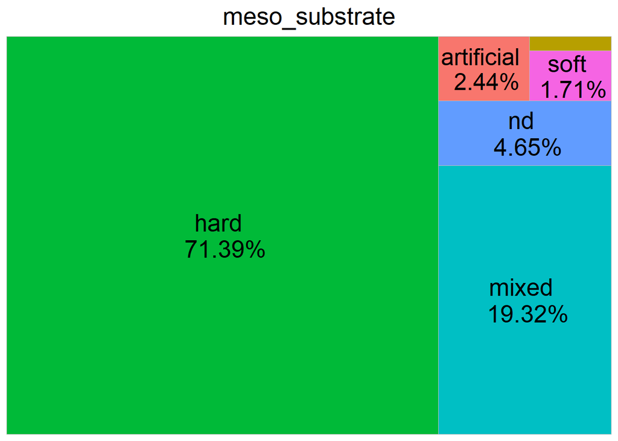

```r
treemap_func = function(dat,var) {
  ggplot(dat,
       aes(area=Count,
           fill=.data[[var]],
           line = "black",
           label=paste0(.data[[var]],
                        " \n ",Percentage,"%"))
       )+
  treemapify::geom_treemap(layout = "squarified")+
  treemapify::geom_treemap_text(place = "centre",
                    size = 20)+
  labs(title = var)+
    theme(plot.title = element_text(hjust = 0.5, size= 20),
          legend.position = "none")

}

treemap_counts <- list()

for (col_name in colnames(count_columns[,-1])) {

  treemap_counts[[col_name]] <- treemap_func(dat= count_results[[col_name]], var = col_name)

}

treemap_counts[[1]]
```

Save all tree maps plots

```r
lapply(names(treemap_counts), function(x){
  ggsave(filename=paste0(x,".tiff"),
         plot=treemap_counts[[x]],
         units = "in", width=12, height=4, dpi=300, compression = 'lzw',
         path = here("Extracted_data_analysis",
                       "tropical",
                       "Output-Visualization",
                     "Treemap_counts"),
         create.dir = T
         )
  })

lapply(names(treemap_counts), function(x){
  ggsave(filename=paste0(x,".png"),
         plot=treemap_counts[[x]],
         units = "in", width=12, height=4, dpi=300,
         path = here("Extracted_data_analysis",
                       "tropical",
                       "Output-Visualization",
                     "Treemap_counts"),
         create.dir = T
         )
  })
```

# 4 COUNT METHODS (PURELY TAXONOMIC STUDIES EXCLUDED)

Remove purely taxonomic studies and subset columns (taxa++ was assigned to studies that led to the description of new species but where also ecological e.g. describing community for a given taxonomic group)

```r
methods <- tropical %>%
  filter(taxonomic_publication == "taxa++" |  is.na(taxonomic_publication) ) %>%
  select(File,
         meso_design,
         meso_replicates,
         temporalReplicates,
         abioticVariablesCollection,
         abioticVariables)

count_columns_method <- methods
```

Prepare data set with columns that need count only and add percentage column

```r
count_columns_method[,] <- lapply(count_columns_method[,], as.factor)

count_results_method <- list()

for (col_name in colnames(count_columns_method)) {
  counts <- count(count_columns_method, !!sym(col_name))

  count_results_method[[col_name]] <- counts

  colnames(count_results_method[[col_name]]) <- c(col_name, "Count")

  count_results_method[[col_name]] %<>%
    filter(
      if_all(.cols = everything(), ~ !grepl("notapp", .x))
    ) %>%
 # delete rows with "notapp"
    tidyr::drop_na()

  count_results_method[[col_name]] %<>%
    mutate(Percentage= round(Count / sum(Count) * 100,1))
}

rm(col_name, counts)

count_results_method <- count_results_method[names(count_results_method) != "File"]
```

Export summary tables

```r
library(openxlsx)

write.xlsx(count_results_method,
           file = here("Extracted_data_analysis",                        "tropical",                        "Output-Transformed_data",
                    "summary_counts_question_4.xlsx"))
```

Create treemaps charts

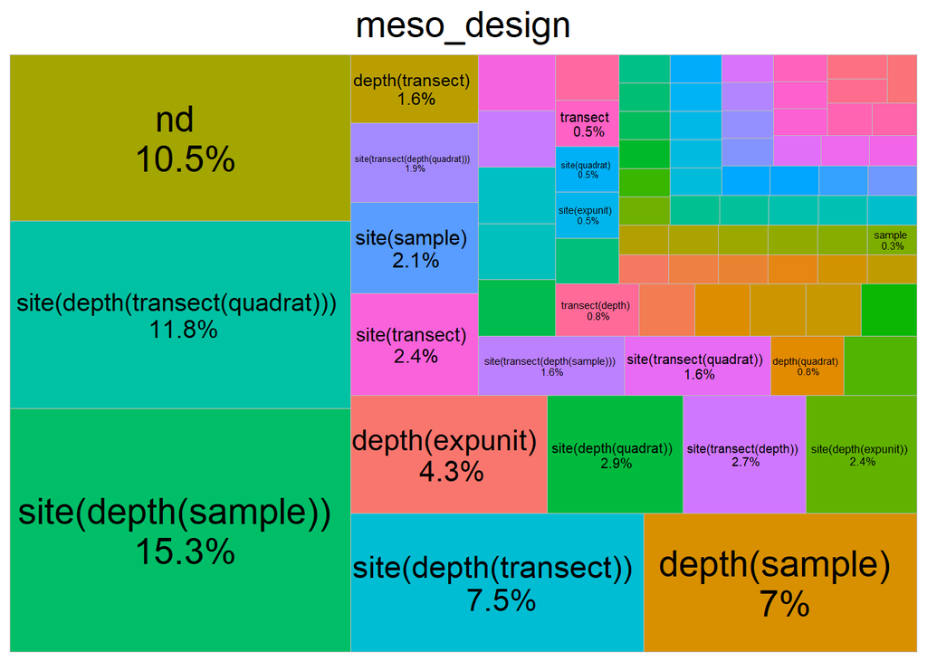

```r
treemap_func = function(dat,var) {
  ggplot(dat,
       aes(area=Count,
           fill=.data[[var]],
           line = "black",
           label=paste0(.data[[var]],
                        " \n ",Percentage,"%"))
       )+
  treemapify::geom_treemap(layout = "squarified")+
  treemapify::geom_treemap_text(place = "centre",
                    size = 20)+
  labs(title = var)+
    theme(plot.title = element_text(hjust = 0.5, size= 20),
          legend.position = "none")

}

treemap_counts <- list()

for (col_name in colnames(count_columns_method[,-1])) {

  treemap_counts[[col_name]] <- treemap_func(dat= count_results_method[[col_name]], var = col_name)

}

treemap_counts[[1]]
```

Save all tree maps plots

```r
lapply(names(treemap_counts), function(x){
  ggsave(filename=paste0("treemap",x,".tiff"),
         plot=treemap_counts[[x]],
         units = "in", width=12, height=4, dpi=300, compression = 'lzw',
         path = here("Extracted_data_analysis","tropical",                        "Output-Visualization","Treemaps_methods"),
         create.dir = T
         )
  })

lapply(names(treemap_counts), function(x){
  ggsave(filename=paste0("treemap",x,".png"),
         plot=treemap_counts[[x]],
         units = "in", width=12, height=4, dpi=300,
         path = here("Extracted_data_analysis",                        "tropical",                        "Output-Visualization","Treemaps_methods"),
         create.dir = T
         )
  })
```

# 5 COUNT COLUMNS SPLIT

Create a list of data frame splitting values

```r
split_columns <- tropical %>%
  select(meso_substrate,
         habit,
         environmentalPosition,
         observationalORexperimental,
         taxonomicTargetLevel,
         indicators,
         collectedDataType,
         molecularAnalyses)


split_columns[,] <- lapply(split_columns[,], as.factor)
```

Prepare data set with columns

```r
split_results <- list()

for (col_name in colnames(split_columns)) {
  # Split the values of each column by "+"
  lvls <- unique(unlist(str_split(split_columns[[col_name]], "\\+")))

  # Initialize a list to store counts for each level
  split_counts <- sapply(lvls, function(y) {
    # Count how many times each unique level appears in the column
    str_count(split_columns[[col_name]], fixed(y))
    }
    )

  split_results[[col_name]] <- split_counts
}
rm(lvls)
```

Add percentage column

```r
split_tot <- list()

for(col_name in colnames(split_columns)) {
  split_results[[col_name]] <- as.data.frame(split_results[[col_name]])

  split_results[[col_name]] %<>% # delete rows with missing values
    select(where(function(x) any(!is.na(x)))) %>%
    select(-any_of("notapp")) %>%
    tidyr::drop_na()

    split_tot[[col_name]] <- as.data.frame(split_results[[col_name]]) %>%
    summarise(across(where(is.numeric), list(sum)))

  split_tot[[col_name]]  <- reshape2::melt(split_tot[[col_name]], id.vars = NULL)

  colnames(split_tot[[col_name]]) <- c(col_name, "Count")

  split_tot[[col_name]] %<>%
        mutate_at(col_name,
                  stringr::str_replace, "_1", "")


  split_tot[[col_name]] %<>%
      mutate(Percentage= round(Count / nrow(split_results[[col_name]] ) * 100,2))

}

rm(col_name)
```

Export summary tables

```r
library(openxlsx)

write.xlsx(split_tot,
           file = here("Extracted_data_analysis",                        "tropical",                        "Output-Transformed_data",
                    "summary_split_counts_question_1_3.xlsx"))
```

Create bar charts for each collected parameter

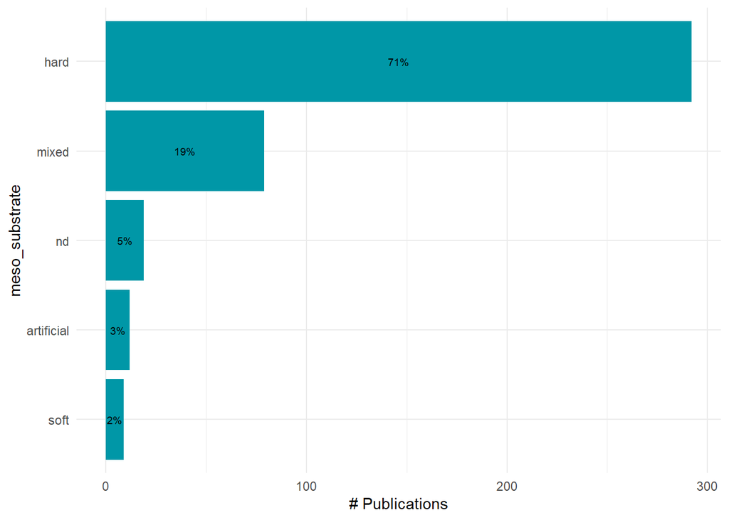

```r
barchart_func = function(dat,var) {

 ggplot(dat,
       aes(x = reorder(.data[[var]], Count), y = Count, fill= .data[[var]])) +
  geom_bar(stat = "identity", fill = "#0097A7") +
  geom_text(
    data = dat %>% filter(Percentage >= 2),
    aes(label = paste0(round(Percentage, 0), "%")),
    position = position_stack(vjust =0.5),
    color = "black",
    size = 2.5
  )+
  labs(y = "# Publications", x = var) +
  theme_minimal() +
  coord_flip()+  # optional: flips for horizontal bars
  theme(legend.position ="none")

}

barchart_counts <- list()

for (col_name in colnames(split_columns)) {

  barchart_counts[[col_name]] <- barchart_func(dat= split_tot[[col_name]], var = as.character(col_name))

}

barchart_counts[[1]]
```

```r
lapply(names(barchart_counts), function(x){
  ggsave(filename=paste0("bar_",x,".tiff"),
         plot=barchart_counts[[x]],
         units = "in", width=12, height=4, dpi=300, compression = 'lzw',
         path = here("Extracted_data_analysis",                        "tropical",                        "Output-Visualization","Barcharts_split"),
         create.dir = T
         )
  })

lapply(names(barchart_counts), function(x){
  ggsave(filename=paste0("bar_",x,".png"),
         plot=barchart_counts[[x]],
         units = "in", width=12, height=4, dpi=300,
         path = here("Extracted_data_analysis",                        "tropical",                        "Output-Visualization","Barcharts_split"),
         create.dir = T
         )
  })
```

# 6 COUNT METHODS (PURELY TAXONOMIC STUDIES EXCLUDED)

Create data frame with subset

```r
split_columns_methods <- methods

split_columns_methods[,] <- lapply(split_columns_methods[,], as.factor)
```

Prepare data set with columns

```r
split_results_methods <- list()

for (col_name in colnames(split_columns_methods)) {
  # Split the values of each column by "+"
  lvls <- unique(unlist(str_split(split_columns_methods[[col_name]], "\\+")))

  # Initialize a list to store counts for each level
  split_counts_methods <- sapply(lvls, function(y) {
    # Count how many times each unique level appears in the column
    str_count(split_columns_methods[[col_name]], fixed(y))
    }
    )

  split_results_methods[[col_name]] <- split_counts_methods
}

rm(lvls)
```

Add percentage column

```r
split_tot_methods <- list()

for(col_name in colnames(split_columns_methods)) {
  split_results_methods[[col_name]] <- as.data.frame(split_results_methods[[col_name]])

  split_results_methods[[col_name]] %<>% # delete rows with missing values
    select(where(function(x) any(!is.na(x)))) %>%
    select(-any_of("notapp")) %>%
    tidyr::drop_na()

    split_tot_methods[[col_name]] <- as.data.frame(split_results_methods[[col_name]]) %>%
    summarise(across(where(is.numeric), list(sum)))

  split_tot_methods[[col_name]]  <- reshape2::melt(split_tot_methods[[col_name]], id.vars = NULL)

  colnames(split_tot_methods[[col_name]]) <- c(col_name, "Count")

  split_tot_methods[[col_name]] %<>%
        mutate_at(col_name,
                  stringr::str_replace, "_1", "")


  split_tot_methods[[col_name]] %<>%
      mutate(Percentage= round(Count / nrow(split_results_methods[[col_name]] ) * 100,2))

}

rm(col_name)
```

Export summary tables

```r
library(openxlsx)

write.xlsx(split_results_methods,
           file = here("Extracted_data_analysis",                        "tropical",                        "Output-Transformed_data",
                    "summary_split_counts_question_4.xlsx"))
```

Create bar charts per each parameter collected

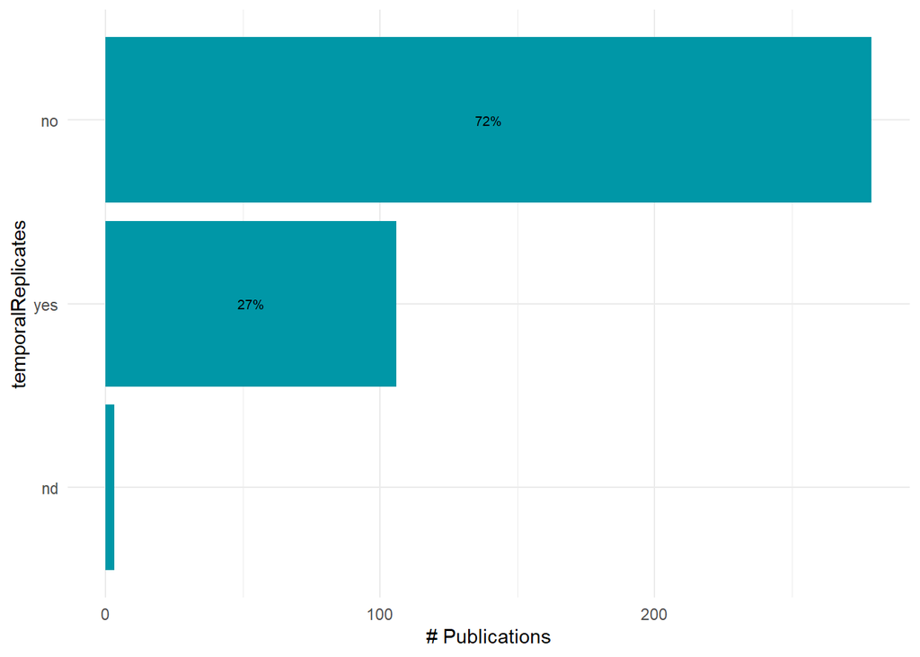

```r
barchart_func = function(dat,var) {

 ggplot(dat,
       aes(x = reorder(.data[[var]], Count), y = Count, fill= .data[[var]])) +
  geom_bar(stat = "identity", fill = "#0097A7") +
  geom_text(
    data = dat %>% filter(Percentage >= 2),
    aes(label = paste0(round(Percentage, 0), "%")),
    position = position_stack(vjust =0.5),
    color = "black",
    size = 2.5
  )+
  labs(y = "# Publications", x = var) +
  theme_minimal() +
  coord_flip()+  # optional: flips for horizontal bars
  theme(legend.position ="none")

}

barchart_split_methods <- list()

for (col_name in colnames(split_columns_methods)) {

  barchart_split_methods[[col_name]] <- barchart_func(dat= split_tot_methods[[col_name]], var = as.character(col_name))

}

barchart_split_methods[[4]]
```

Export bar charts in a dedicated folder

```r
lapply(names(barchart_counts), function(x){
  ggsave(filename=paste0("bar_",x,".tiff"),
         plot=barchart_counts[[x]],
         units = "in", width=12, height=4, dpi=300, compression = 'lzw',
         path = here("Extracted_data_analysis",                        "tropical",                        "Output-Visualization","Barcharts_split_methods"), create.dir = T
         )
  })

lapply(names(barchart_counts), function(x){
  ggsave(filename=paste0("bar_",x,".png"),
         plot=barchart_counts[[x]],
         units = "in", width=12, height=4, dpi=300,
         path = here("Extracted_data_analysis",                        "tropical",                        "Output-Visualization","Barcharts_split"), create.dir = T
         )
  })
```

# 7 PUBLICATIONS PER DEPTH

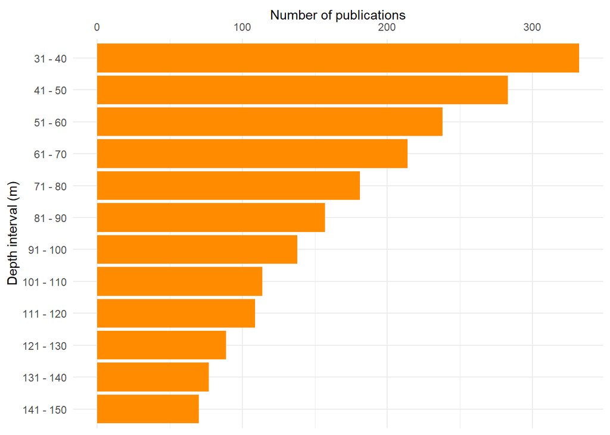

```r
tropical$mininumSurveyedDepthInMeters <- as.numeric(tropical$mininumSurveyedDepthInMeters)
tropical$maximumSurveyedDepthInMeters <- as.numeric(tropical$maximumSurveyedDepthInMeters)

# Define depth bins
bins <- seq(31, 151, by = 10)

# Create a data frame to hold bin counts
pubs_depth <- data.frame(
  bin_start = bins[-length(bins)],
  bin_end = bins[-1]-1,
  count = 0
)

# For each bin, count how many studies cover that depth range
for (i in 1:nrow(pubs_depth)) {
  bin_start <- pubs_depth$bin_start[i]
  bin_end <- pubs_depth$bin_end[i]

  pubs_depth$count[i] <- sum(tropical$maximumSurveyedDepthInMeters >= bin_start & tropical$mininumSurveyedDepthInMeters < bin_end, na.rm = TRUE)
}

pubs_depth$depth_bin <- paste(pubs_depth$bin_start, "-", pubs_depth$bin_end)

pubs_depth$depth_bin <- reorder(pubs_depth$depth_bin, -pubs_depth$bin_start)


ggplot(pubs_depth, aes(x = factor(depth_bin), y = count)) +
  geom_bar(stat = "identity", fill = "darkorange") +
  labs(x = "Depth interval (m)", y = "Number of publications") +
  theme_minimal()+
  coord_flip()+
  scale_y_continuous(position="right")
```

# 8 PLATFORM BY DEPTH

Create a platform by depth data frame and keep meso_samplingPlatform

```r
platform_depth <- tropical %>%
  select(File,
         mininumSurveyedDepthInMeters,
         maximumSurveyedDepthInMeters,
         meso_direct_indirect,
         meso_samplingPlatform,
         max_depth_hov, min_depth_hov,
         max_depth_rov, min_depth_rov,
         max_depth_ccr, min_depth_ccr,
         max_depth_open, min_depth_open,
         max_depth_scuba, min_depth_scuba
         )
```

Split the platform column in one binary column per platform

```r
platform_lvls <-
  unique(
    unlist(
      str_split(platform_depth$meso_samplingPlatform, "\\+")
                               )
                        )

platform_lvls<- platform_lvls[! platform_lvls %in% c("",NA,"notapp",",","nd")]

platform_depth[,platform_lvls] <- sapply(platform_lvls,
                                      function(y){
                                        str_count(platform_depth$meso_samplingPlatform, y)
                                        }
                                      )

rm(platform_lvls)

platform_depth[,-c(1:15)] <- lapply(platform_depth[,-c(1:15)], as.numeric)

platform_depth[,c(1:15)] <- lapply(platform_depth[,c(1:15)], as.character)


platform_depth %<>%
  rename(open_direct = open,
         ccr_direct = ccr,
         scuba_direct = scuba)  %>%
  select(-meso_samplingPlatform)
```

Create a summary table with # studies per platform

```r
platform_summary <- platform_depth %>%
  summarise(across(where(is.numeric), ~ sum(.x, na.rm = TRUE)))

platform_summary <- as.data.frame(t(platform_summary))

platform_summary %<>%
  mutate(Platform = rownames(platform_summary)) %>%
  rename(Count = V1) %>%
  relocate(Count,.after = where(is.character))

platform_summary
```

```
##                  Platform Count
## acou                 acou    27
## bruv                 bruv     8
## tcs                   tcs    16
## dredge             dredge    15
## fishery           fishery     6
## scuba_direct scuba_direct    75
## trawl               trawl     2
## open_direct   open_direct   168
## hov                   hov    86
## rov                   rov   101
## ccr_direct     ccr_direct    80
## auv                   auv     9
## grab                 grab    13
## vams                 vams     2
## mixed               mixed     1
## drop                 drop     8
## station           station     1
```

Create a column with the number of platforms per study

```r
platform_per_record <- platform_depth %>%
  filter(meso_direct_indirect != "nd") %>%
   mutate(
     platform_per_record = rowSums(
     across(
       where(is.numeric)
       )
     )
   )

platform_per_record$platform_per_record <- as.factor(platform_per_record$platform_per_record)
```

Calculate number of records by number of platforms in %

```r
platform_per_record <- platform_per_record %>%
  group_by(platform_per_record) %>%
  summarise(n_records = length(platform_per_record)) %>%
  mutate(percentage= round(n_records / sum(n_records) * 100,1))

platform_per_record
```

```
## # A tibble: 4 × 3
##   platform_per_record n_records percentage
##   <fct>                   <int>      <dbl>
## 1 1                         309       69.9
## 2 2                          98       22.2
## 3 3                          27        6.1
## 4 4                           8        1.8
```

Keep most common visual platforms only

```r
platform_depth_mod <- cbind(platform_depth[,c(1:14)],
                            platform_depth$ccr_direct,
                            platform_depth$open_direct,
                            platform_depth$scuba_direct,
                            platform_depth$hov,
                            platform_depth$rov)

names(platform_depth_mod) <- gsub("platform_depth\\$", "", names(platform_depth_mod))
```

Set max depth of studies with max depth > 150 to 150 so they fit into the plot

```r
platform_depth_long <- within(platform_depth_mod, rm(mininumSurveyedDepthInMeters, maximumSurveyedDepthInMeters, max_depth_direct, meso_direct_indirect, hov, rov, open_direct, ccr_direct, scuba_direct))

platform_depth_long[,-1] <- lapply(platform_depth_long[,-1], as.numeric)

str(platform_depth_long)
```

```
## 'data.frame':    445 obs. of  11 variables:
##  $ File           : chr  "AbdulWahabEtAl_2018_Biodiversity_spatial_patterns.md" "AbesamisEtAl_2018_Benthic_habitat_fish.md" "AlbanoEtAl_2011_challenge_small_rare.md" "AlbeldaEtAl_2020_Juvenile_scleractinian_assemblage.md" ...
##  $ max_depth_hov  : num  NA NA NA NA NA NA NA NA NA 150 ...
##  $ min_depth_hov  : num  NA NA NA NA NA NA NA NA NA 45 ...
##  $ max_depth_rov  : num  NA NA NA NA NA NA 100 70 NA NA ...
##  $ min_depth_rov  : num  NA NA NA NA NA NA 20 20 NA NA ...
##  $ max_depth_ccr  : num  NA NA NA NA NA NA NA NA NA NA ...
##  $ min_depth_ccr  : num  NA NA NA NA NA NA NA NA NA NA ...
##  $ max_depth_open : num  NA NA NA 40 NA NA 53 NA NA NA ...
##  $ min_depth_open : num  NA NA NA 3 NA NA 10 20 NA NA ...
##  $ max_depth_scuba: num  NA NA NA NA NA 55 NA NA NA NA ...
##  $ min_depth_scuba: num  NA NA 1 NA 72 4 NA NA NA NA ...
```

```r
platform_depth_long  %<>%
  mutate(max_depth_scuba = case_when(max_depth_scuba >= 150 ~ 150,
                               TRUE ~ max_depth_scuba)
         ) %>%
  mutate(max_depth_hov = case_when(max_depth_hov >= 150 ~ 150,
                               TRUE ~ max_depth_hov)
         ) %>%
  mutate(max_depth_rov = case_when(max_depth_rov >= 150 ~ 150,
                               TRUE ~ max_depth_rov)
         ) %>%
  mutate(max_depth_ccr = case_when(max_depth_ccr >= 150 ~ 150,
                               TRUE ~ max_depth_ccr)) %>%
  mutate(max_depth_open = case_when(max_depth_open >= 150 ~ 150,
                               TRUE ~ max_depth_open))
```

Set min depth of studies with min depth <30 to 30 so they fit into the plot

```r
platform_depth_long %<>%
  mutate(min_depth_scuba = case_when(min_depth_scuba <= 30 ~ 30,
                               TRUE ~ min_depth_scuba)
         ) %>%
  mutate(min_depth_hov = case_when(min_depth_hov <= 30 ~ 30,
                               TRUE ~ min_depth_hov)
         ) %>%
  mutate(min_depth_rov = case_when(min_depth_rov <= 30 ~ 30,
                               TRUE ~ min_depth_rov)
         ) %>%
  mutate(min_depth_ccr = case_when(min_depth_ccr <= 30 ~ 30,
                               TRUE ~ min_depth_ccr)) %>%
  mutate(min_depth_open = case_when(min_depth_open <= 30 ~ 30,
                               TRUE ~ min_depth_open))
```

Convert platform_depth_long to long format

```r
platform_min_depth_long <- platform_depth_long %>%
  select(-c(max_depth_hov, max_depth_rov, max_depth_open, max_depth_scuba, max_depth_ccr))


platform_min_depth_long[,c(1,2)] <- lapply(platform_min_depth_long[,c(1,2)], as.factor)

platform_min_depth_long %<>%
  reshape2::melt(platform_min_depth_long,
                 id.vars = c("File"),
                 measure.vars = grep("^min_depth_|^max_depth_",
                                     names(platform_min_depth_long),
                                     value = TRUE),
                 variable.name = "Platform",
                 value.name = "min_depth"
                 )
platform_max_depth_long <- platform_depth_long %>%
    select(-c(min_depth_hov, min_depth_rov, min_depth_open, min_depth_scuba, min_depth_ccr))

platform_max_depth_long %<>%
    reshape2::melt(platform_max_depth_long,
                 id.vars = c("File"),
                 measure.vars = grep("^min_depth_|^max_depth_",
                                     names(platform_max_depth_long),
                                     value = TRUE),
                 variable.name = "Platform",
                 value.name = "max_depth"
                 )

platform_depth_lat_long <- cbind(platform_min_depth_long, platform_max_depth_long$max_depth)

rm(platform_min_depth_long, platform_max_depth_long)
```

```r
platform_depth_lat_long %<>%
  rename(max_depth =`platform_max_depth_long$max_depth`)

platform_depth_lat_long$Platform <- gsub("min_depth_", "", platform_depth_lat_long$Platform)

platform_depth_lat_long$Platform <- gsub("max_depth_", "", platform_depth_lat_long$Platform)
```

Set proper labelling for platform

```r
platform_depth_lat_long %<>%
  mutate(Platform = case_when(Platform == "ccr" ~ "CCR",
                              Platform == "scuba" ~ "SCUBA",
                              Platform == "open" ~ "OC",
                              Platform == "rov" ~ "ROV",
                              Platform == "hov" ~ "HOV",
                              TRUE ~ Platform)
         ) %>%
  mutate(Platform = as.factor(Platform))
```

Add visual column to reorder platform

```r
platform_depth_lat_long %<>%
  mutate(Visual = as.factor(case_when(Platform == "OC" |
                                      Platform == "SCUBA" |
                                      Platform == "CCR" ~ "direct",
                            TRUE ~ "indirect" )
  )
  )

platform_depth_lat_long %<>%
  mutate(Platform = forcats::fct_reorder(Platform, as.integer(Visual)))
```

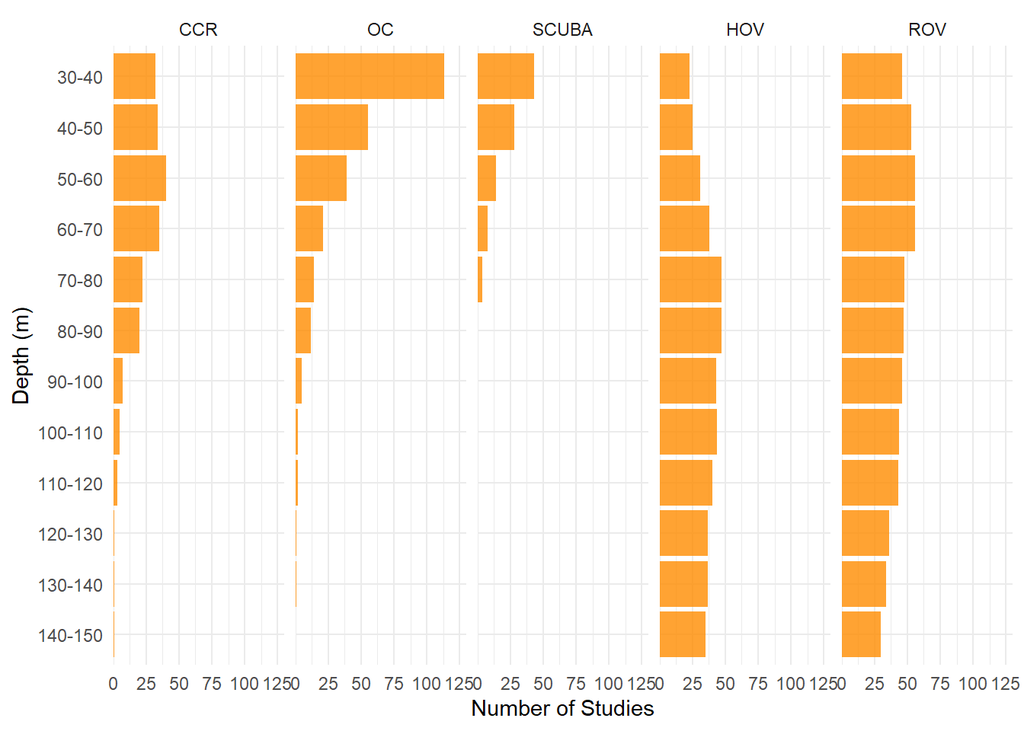

```r
depth_bins <- tibble(
  bin_start = seq(-30, -140, by = -10),
  bin_end   = seq(-40, -150, by = -10)
) %>%
  mutate(bin_label = paste0(abs(bin_start), "-", abs(bin_end)))

platform_depth_lat_long <- platform_depth_lat_long %>%
  mutate(
    min_depth = as.numeric(min_depth),  # positive e.g., 30
    max_depth = as.numeric(max_depth)   # positive e.g., 150
  )

expanded_data <- platform_depth_lat_long %>%
  tidyr::crossing(depth_bins) %>%
  # Convert study range to negative depths: [-max_depth, -min_depth]
  filter(bin_end >= -max_depth, bin_start <= -min_depth) %>%
  mutate(
    bin_label = factor(bin_label, levels = rev(depth_bins$bin_label))
  )

# Plot with count labels on the right
platform_depth_plot <- ggplot(expanded_data, aes(x = bin_label)) +
  geom_bar(position = "stack", alpha= 0.8, fill= "darkorange") +
  scale_y_continuous(name = "Number of Studies",
                     expand = expansion(mult = c(0, 0.15))) +  # Make room for text
  scale_x_discrete(name = "Depth (m)") +
  coord_flip() +  # Depth on y-axis (shallow at top)
  facet_wrap(~ Platform, nrow = 1) +
  theme_minimal() +
  theme(legend.position = "none")

platform_depth_plot
```

Export bar plot of most common platform per depth interval

```r
ggsave("platform_depth_plot.tiff",
       plot = platform_depth_plot,
       units = "in", width = 8, height = 6, dpi = 300, compression = 'lzw',
       path = here ("Extracted_data_analysis",                        "tropical",                        "Output-Visualization"))

ggsave("platform_depth_plot.png",
       plot = platform_depth_plot,
       units = "in", width = 8, height = 5,
       path = here ("Extracted_data_analysis", "tropical",                      "Output-Visualization"))
```

# 9 DIRECT - INDIRECT BY DECADE

```r
dir_ind_by_decade <- tropical

dir_ind_by_decade %<>%
         mutate(decade = case_when(publicationYear >= 1960 & publicationYear < 1970 ~ "1970-1979",
                                 publicationYear >= 1970 & publicationYear < 1980 ~ "1970-1979",
                                 publicationYear >= 1980 & publicationYear < 1990 ~ "1980-1989",
                                 publicationYear >= 1990 & publicationYear < 2000 ~ "1990-1999",
                                 publicationYear >= 2000 & publicationYear < 2010 ~ "2000-2009",
                                 publicationYear >= 2010 & publicationYear < 2020 ~ "2010-2019",
                                 publicationYear >= 2020 ~ "2020-2023")
              )

dir_ind_by_decade_lat <- dir_ind_by_decade

dir_ind_by_decade <- dir_ind_by_decade [, c("meso_direct_indirect","decade")] %>%
  group_by(decade,meso_direct_indirect) %>%
  tally()

colnames(dir_ind_by_decade) <- c("Decade", "Technique","Count")

unique(dir_ind_by_decade$Technique)
```

```
## [1] "direct"   "mixed"    "indirect" "nd"
```

```r
dir_ind_by_decade %<>%
  filter(Technique != "nd" & Technique != "NA") %>% #remove nd from viz because they accounted for a really small percentage
  group_by(Decade) %>%
  mutate(Percentage = round(Count / sum(Count) * 100,1))
```

Make bar plot of technique by decade

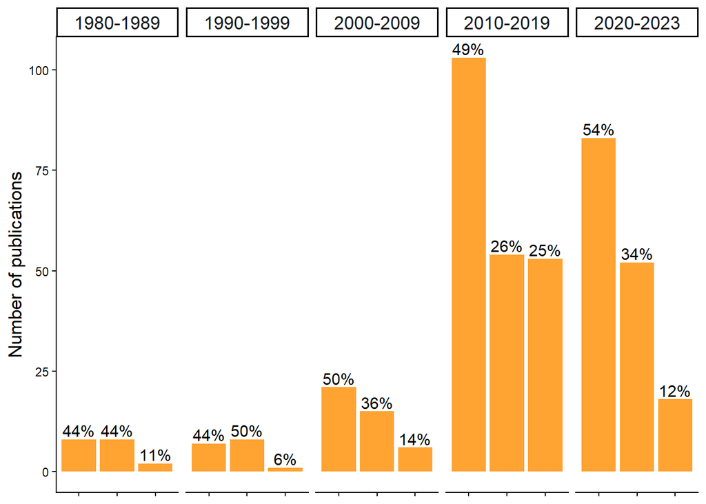

```r
technique_decade_barplot <- ggplot(subset(dir_ind_by_decade,
              dir_ind_by_decade$Decade != "1970-1979"),
       aes(x=Technique, y=Count, label = Technique)
       ) +
  geom_bar(position="dodge",
           stat="identity", alpha= 0.8, fill = "darkorange" ) +
  geom_text(aes(label = paste(round(Percentage,0),"%", sep="")),
            parse = F,
            vjust = -0.25,
            size=3.9)+
  facet_grid(~ Decade,
             switch = "y") +
  theme_classic() +
  theme(legend.position = "bottom",
        legend.text = element_text(size = 10),
        axis.text.x = element_blank(),
        axis.text.y = element_text(size=8.7),
        axis.title.x = element_blank(),
        axis.title.y = element_text(size=13),
        strip.text = element_text(size = 13))+
  labs(y= "Number of publications")

technique_decade_barplot
```

Export bar plot of technique by decade

```r
ggsave("technique_decade_barplot.tiff",
       plot = technique_decade_barplot,
       units = "in", width = 7, height = 6, dpi = 300, compression = 'lzw',
       path = here ("Extracted_data_analysis",                        "tropical",                        "Output-Visualization"))

ggsave("technique_decade_barplot.png",
       plot = technique_decade_barplot,
       units = "in", width = 7, height = 6,
       path = here ("Extracted_data_analysis",                        "tropical",                        "Output-Visualization"))
```

# 10 FIELD & INDICATORS

Create subset for field & indicators

```r
field_merged <- tropical[,c(59:length(tropical))]

field_merged[,] <- lapply(field_merged[,], as.numeric)

colSums(field_merged)
```

```
##                  field_cons              field_commdesc
##                          24                         147
##                   field_map                field_impass
##                          46                          67
##                 field_troph                  field_taxo
##                          37                         107
##                  field_dist                  field_aqua
##                         170                           1
##                field_method                field_physio
##                          13                         124
##                  field_func               field_habtype
##                          17                           0
##               field_fishery                 field_stock
##                           8                           7
##                 field_paleo                 field_phylo
##                           0                          31
##                  field_rest               field_archaeo
##                           1                           0
##                 field_micro           field_biomedicine
##                           7                           1
##                  field_chem     field_Molecular_ecology
##                           1                         121
##             field_Acoustics field_environmental_drivers
##                          26                         137
##             field_Behaviour         field_Geomorphology
##                          27                          13
##              field_Taxonomy
##                          92
```

Select only the most common fields

```r
field_merged <- field_merged[, colSums(field_merged) > 30]

field_merged$field_Taxonomy <- NULL
field_merged$field_taxo <- NULL


colSums(field_merged)
```

```
##              field_commdesc                   field_map
##                         147                          46
##                field_impass                 field_troph
##                          67                          37
##                  field_dist                field_physio
##                         170                         124
##                 field_phylo     field_Molecular_ecology
##                          31                         121
## field_environmental_drivers
##                         137
```

```r
field_merged <- field_merged[, order(colSums(field_merged), decreasing = F)]

colSums(field_merged)
```

```
##                 field_phylo                 field_troph
##                          31                          37
##                   field_map                field_impass
##                          46                          67
##     field_Molecular_ecology                field_physio
##                         121                         124
## field_environmental_drivers              field_commdesc
##                         137                         147
##                  field_dist
##                         170
```

Rename fields with long version names

```r
field_merged %<>%
  rename(`Biodiversity and \n community structure (146)` = field_commdesc,
         `Distribution and \n connectivity (171)` = field_dist,
         `Disturbances (66)` = field_impass,
         `Mapping (46)` = field_map,
         `Physiology (124)` = field_physio,
         `Phylogenesis (31)` = field_phylo,
         `Trophic ecology (37)` = field_troph,
         `Molecular ecology (120)` = field_Molecular_ecology,
         `Environmental drivers and \n spatio-temporal patterns (136)` = field_environmental_drivers
         )
colSums(field_merged)
```

```
##                                           Phylogenesis (31)
##                                                          31
##                                        Trophic ecology (37)
##                                                          37
##                                                Mapping (46)
##                                                          46
##                                           Disturbances (66)
##                                                          67
##                                     Molecular ecology (120)
##                                                         121
##                                            Physiology (124)
##                                                         124
## Environmental drivers and \n spatio-temporal patterns (136)
##                                                         137
##               Biodiversity and \n community structure (146)
##                                                         147
##                      Distribution and \n connectivity (171)
##                                                         170
```

Prepare the indicator matrix

```r
ind_matrix <- split_results[["indicators"]]
```

Select only the most common indicators

```r
colSums(ind_matrix)
```

```
##        Abundance            Cover        Diversity          Habitat
##               93              135              180               57
##    Morphological       complexity             Size geneticSequences
##              143                3               70              120
##          Density             taxo          Biomass          Trophic
##               36               90               26               37
##         rugosity        Mortality    Physiological           growth
##                1               15               94               22
##      Recruitment             surv              sex           Health
##               14               16                7               28
##        Behaviour              NIS          disease           impact
##               17                8                6                5
##           ALDFGs           Litter             func        fecundity
##                3                4               10                1
```

```r
ind_common_matrix <- ind_matrix[, colSums(ind_matrix) > 30]

colSums(ind_common_matrix)
```

```
##        Abundance            Cover        Diversity          Habitat
##               93              135              180               57
##    Morphological             Size geneticSequences          Density
##              143               70              120               36
##             taxo          Trophic    Physiological
##               90               37               94
```

```r
ind_common_matrix <- ind_common_matrix[, order(colSums(ind_common_matrix), decreasing = TRUE)]

ind_common_matrix <- as.data.frame(ind_common_matrix)

ind_common_matrix <- ind_common_matrix[!purrr::map_lgl(ind_common_matrix, ~ all(is.na(.)))] # remove empty column
```

Remove taxonomy studies which have a dedicated section

```r
ind_common_matrix$taxo <- NULL

colSums(ind_common_matrix)
```

```
##        Diversity    Morphological            Cover geneticSequences
##              180              143              135              120
##    Physiological        Abundance             Size          Habitat
##               94               93               70               57
##          Trophic          Density
##               37               36
```

Rename indicators with long version names

```r
ind_common_matrix %<>%
  rename(`Abundance \n (92)` = Abundance,
         `Cover \n (134)` = Cover,
         `Diversity \n (179)` = Diversity,
         `Habitat \n (56)` = Habitat,
         `Morphology \n (142)` = Morphological,
         `Size \n (70) ` = Size,
         `Density \n (36)` = Density,
         `Physiological \n indicator \n (94)` = Physiological,
         `Trophic \n (37)` = Trophic,
         `Genetic \n sequence \n (120)` = geneticSequences
         )

colSums(ind_common_matrix)
```

```
##                 Diversity \n (179)                Morphology \n (142)
##                                180                                143
##                     Cover \n (134)       Genetic \n sequence \n (120)
##                                135                                120
## Physiological \n indicator \n (94)                  Abundance \n (92)
##                                 94                                 93
##                      Size \n (70)                     Habitat \n (56)
##                                 70                                 57
##                    Trophic \n (37)                    Density \n (36)
##                                 37                                 36
```

Multiply the transpose of the field matrix with the indicator matrix

```r
co_occurrence_matrix <- t(as.matrix(field_merged)) %*% as.matrix(ind_common_matrix)
```

Reshape the co-occurrence matrix for plotting}

```r
co_occurrence_df <- reshape2::melt(co_occurrence_matrix)

colnames(co_occurrence_df) <- c("Field", "Indicator", "Count")
```

Plot the heatmap

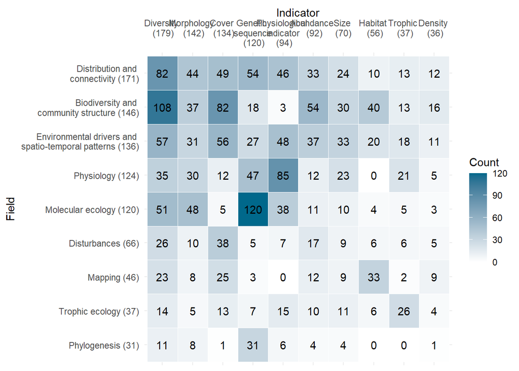

```r
field_ind_heat <- ggplot(co_occurrence_df, aes(x = Indicator, y = Field, fill = Count)) +
  geom_tile(color = "white") +
  scale_fill_gradient(low = "white", high = "deepskyblue4") +
  geom_text(aes(label = Count), color = "black") +
  theme_minimal()+
  scale_x_discrete(position="top")

field_ind_heat
```

Export plot

```r
ggsave("field_ind_heat.png",
       units = "in", width = 12.5, height = 5.5,
       path = here ("Extracted_data_analysis", "tropical",                        "Output-Visualization"))
```

## 10.1 Calculate # of ecological indicators per record

Create a column with the sum of ecological indicators values to see how many different sampling units were adopted by each study

```r
ind_summary <- as.data.frame(split_results[["indicators"]])

ind_summary <- ind_summary[!purrr::map_lgl(ind_summary, ~ all(is.na(.)))] # remove empty column

ind_summary %<>%  rowwise() %>%
   mutate(ind_per_record =  sum(c_across(where(is.numeric))))
```

Calculate number of records by number of sampling units in %

```r
ind_summary$ind_per_record <- as.factor(ind_summary$ind_per_record)

ind_per_record <- ind_summary %>%
  group_by(ind_per_record) %>%
  summarise(n_records = length(ind_per_record)) %>%
  mutate(percentage= round(n_records / sum(n_records) * 100,1))

ind_per_record
```

```
## # A tibble: 10 × 3
##    ind_per_record n_records percentage
##    <fct>              <int>      <dbl>
##  1 0                      3        0.7
##  2 1                     67       15.1
##  3 2                    135       30.3
##  4 3                    140       31.5
##  5 4                     49       11
##  6 5                     31        7
##  7 6                     11        2.5
##  8 7                      6        1.3
##  9 8                      2        0.4
## 10 9                      1        0.2
```

# 11 SAMPLING UNIT

## 11.1 Prepare a data frame for sampling unit

```r
sampling_df <- tropical %>%
  filter(is.na(taxonomic_publication)) %>% # remove purely taxonomic studies
  select(File,recordTitle,DOI,publicationYear,mininumSurveyedDepthInMeters,maximumSurveyedDepthInMeters,samplingUnit)

sampling_df %>% tidyr::drop_na(samplingUnit)
sampling_df[!is.na(sampling_df$samplingUnit),]

sampling_df %<>%
  filter(samplingUnit != "notapp")

sampling_df$samplingUnit <- as.character(sampling_df$samplingUnit)
```

Prepare columns per sampling units

```r
sampling_lvls <- unique(unlist(str_split(sampling_df$samplingUnit,
                                         "\\+")
                               )
                        )

rownames(is.na(sampling_df$samplingUnit))
```

```r
sampling_df[,sampling_lvls] <- sapply(sampling_lvls,
                                      function(y){
                                        str_count(sampling_df$samplingUnit, y)
                                        }
                                      )

rm(sampling_lvls)

colnames(sampling_df)
```

```
##  [1] "File"                         "recordTitle"
##  [3] "DOI"                          "publicationYear"
##  [5] "mininumSurveyedDepthInMeters" "maximumSurveyedDepthInMeters"
##  [7] "samplingUnit"                 "quadrat"
##  [9] "sample"                       "transect"
## [11] "permquad"                     "pit"
## [13] "permtrans"                    "expunit"
## [15] "lit"                          "nd"
## [17] "permlit"                      "roaming_transect"
## [19] "random_swim"                  "arms"
## [21] "plotless"                     "stationary"
## [23] "radial_transect"
```

## 11.2 Calculate # of sampling unit per record

Create a column with the sum of sampling units values to see how many different sampling units were adopted by each study

```r
sampling_df %<>%
   mutate(type_per_record = rowSums(across(quadrat:permlit)
                        )
   )
```

Calculate number of records by number of sampling units in %

```r
sampling_df$type_per_record <- as.factor(sampling_df$type_per_record)

sampling_unit_per_record <- sampling_df %>%
  group_by(type_per_record) %>%
  summarise(n_records = length(type_per_record)) %>%
  mutate(percentage= round(n_records / sum(n_records) * 100,0))

sampling_unit_per_record
```

```
## # A tibble: 4 × 3
##   type_per_record n_records percentage
##   <fct>               <int>      <dbl>
## 1 0                       5          1
## 2 1                     285         76
## 3 2                      71         19
## 4 3                      15          4
```

Create a data frame with number of publication per sampling unit type

```r
sampling_unit_tot <- sampling_df  %>%
  summarise(across(c(8:(length(sampling_df)-1)),
                   list(sum)))

sampling_unit_tot <- reshape2::melt(sampling_unit_tot)
colnames(sampling_unit_tot) <- c("Sampling_unit", "Count")

sampling_unit_tot %<>%
        mutate_at("Sampling_unit",
                  stringr::str_replace, "_1", "")
```

## 11.3 Simplified sampling units

Create a column with a simplified sampling units for transect and quadrat

```r
  sampling_unit_tot %<>%
       mutate(Sampling_unit_macro = case_when(Sampling_unit == 'quadrat' |
                                  Sampling_unit == "permquad" ~ "Quadrat",
                                  Sampling_unit == "transect"|
                                  Sampling_unit == "lit" |
                                  Sampling_unit == "pit" |
                                  Sampling_unit == "permlit" |
                                  Sampling_unit == "permtrans" |
                                  Sampling_unit == "circular_transect" |
                                  Sampling_unit == "radial_transect"~ "Transect",
                                  Sampling_unit == "nd" ~ "ND",
                                  Sampling_unit == "stationary" ~ "Stationary",
                                  Sampling_unit == "expunit" ~ "Experimental unit",
                                  Sampling_unit == "sample" ~ "Sample",
                                  .default = "Other")
              )

# Change columns order
sampling_unit_tot <- cbind(sampling_unit_tot$Sampling_unit_macro,
                       sampling_unit_tot$Sampling_unit,
                       sampling_unit_tot$Count)

colnames(sampling_unit_tot) <- c("Sampling_unit_macro","Sampling_unit","Count")

sampling_unit_tot <- as.data.frame(sampling_unit_tot)

sampling_unit_tot[,1:2] <- lapply(sampling_unit_tot[,1:2], as.factor)
sampling_unit_tot$Count <- as.numeric(sampling_unit_tot$Count)

sampling_unit_simplified <- aggregate(Count ~ Sampling_unit_macro, data = sampling_unit_tot, FUN = sum)

sampling_unit_simplified %<>%
  group_by(Sampling_unit_macro) %>%
  mutate(Percentage_macro= round(Count / sum(sampling_unit_simplified$Count) * 100,1))

sampling_unit_simplified
```

```
## # A tibble: 7 × 3
## # Groups:   Sampling_unit_macro [7]
##   Sampling_unit_macro Count Percentage_macro
##   <fct>               <dbl>            <dbl>
## 1 Experimental unit      46              9.3
## 2 ND                     21              4.3
## 3 Other                  10              2
## 4 Quadrat               111             22.5
## 5 Sample                166             33.7
## 6 Stationary             10              2
## 7 Transect              129             26.2
```

Build a treemap with simplified sampling unit

```r
library(treemapify)

RdYlBu <- RColorBrewer::brewer.pal(7, "RdYlBu")
RdYlBu
```

```
## [1] "#D73027" "#FC8D59" "#FEE090" "#FFFFBF" "#E0F3F8" "#91BFDB" "#4575B4"
```

```r
sampling_simplified_treemap <-
ggplot(sampling_unit_simplified,
       aes(area=Count,
           fill=Sampling_unit_macro,
           line = "black",
           label=paste0(Sampling_unit_macro, " \n ",Percentage_macro,"%"))
       )+
  treemapify::geom_treemap(layout = "squarified")+
  geom_treemap_text(place = "centre",
                    size = 20)+
    theme(plot.title = element_text(hjust = 0.5, size= 20),
          legend.position = "none")+
  scale_fill_manual(values= c("#FC8D59", "#FEE090","#FFFFBF", "#E0F3F8", "#D73027", "#91BFDB", "#4575B4"))
  scale_fill_brewer(palette = "RdYlBu")
```

[output not shown]

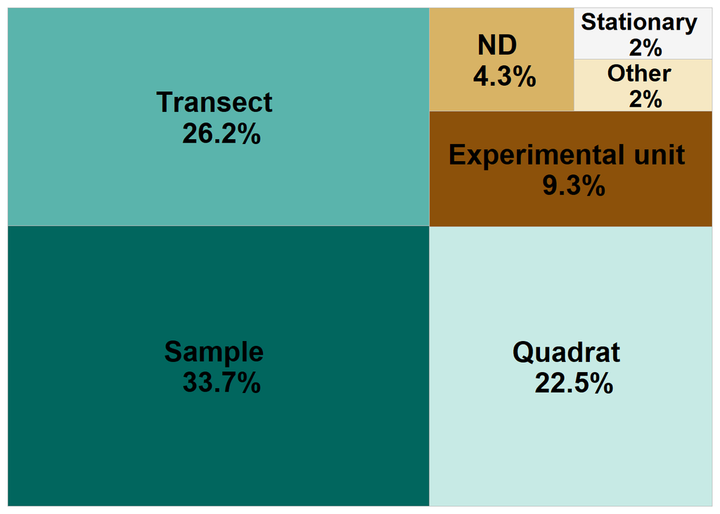

```r
sampling_unit_simplified %<>%
  mutate(case_when(Sampling_unit_macro == "Experimental unit" ~
          "Experimental \n unit", T ~ Sampling_unit_macro))

sampling_simplified_treemap <-
ggplot(sampling_unit_simplified,
       aes(area=Count,
           fill= reorder(Sampling_unit_macro, -Count),
           line = "black",
           label=paste0(Sampling_unit_macro, " \n ",Percentage_macro,"%"))
       )+
  treemapify::geom_treemap(layout = "squarified")+
  geom_treemap_text(place = "centre", fontface = "bold",
                    size = 20)+
    theme(plot.title = element_text(hjust = 0.5, size= 20),
          legend.position = "none")+
  scale_fill_manual(values=c("#01665E","#5AB4AC","#C7EAE5", "#8C510A","#D8B365","#F6E8C3","#F5F5F5")) # selected from "BrBG" palette of RBrewer

sampling_simplified_treemap
```

Export sampling_simplified_treemap

```r
ggsave("sampling_simplified_treemap.png",
       plot = sampling_simplified_treemap,
       units = "in", width = 7, height = 6,
       path = here ("Extracted_data_analysis",
                    "tropical",
                    "Output-Visualization"))
```

Export sampling_unit_tot table for supplementary materials

```r
library(openxlsx)

openxlsx::write.xlsx(sampling_unit_tot,
           file = here("Extracted_data_analysis",                        "tropical",                        "Output-Transformed_data",
                    "sampling_unit_tot.xlsx"))
```

## 11.4 Quadrat extracted from transect

```r
print(paste("Number of publications where quadrat is the sampling unit or one of the sampling unit: ",
            nrow(quad_design <- subset(tropical,grepl("quad", samplingUnit)
                                       )                                                                  )
            )
)
```

```
## [1] "Number of publications where quadrat is the sampling unit or one of the sampling unit:  110"
```

```r
print(paste("Number of publications where quadrats were collected along transects: ", nrow(subset(quad_design,
            grepl("transect\\(quadrat", meso_design) |
              grepl("transect\\(depth\\(quadrat", meso_design)
            )
     )
)
)
```

```
## [1] "Number of publications where quadrats were collected along transects:  81"
```

# 12 DATA TYPE

```r
data_type <- count_results[["collectedDataType"]]

data_type$Percentage <- round(data_type$Percentage, 1)

data_type
```

```
## # A tibble: 29 × 3
##    collectedDataType             Count Percentage
##    <fct>                         <int>      <dbl>
##  1 photo                            49       11
##  2 photo+specimen                   51       11.5
##  3 photo+specimen+sediment           1        0.2
##  4 photo+specimen+sediment+video     3        0.7
##  5 photo+specimen+video              9        2
##  6 photo+specimen+video+visual       4        0.9
##  7 photo+specimen+visual             7        1.6
##  8 photo+specimen+water              1        0.2
##  9 photo+video                      14        3.1
## 10 photo+video+visual                4        0.9
## # ℹ 19 more rows
```

Lump uncommon combination into “Other”

```r
data_type_simplified <- data_type %>%
  rename(`Data type`= collectedDataType) %>%
  mutate(`Data type` = as.character(`Data type`)) %>%
  filter(Percentage > 2) %>%
  bind_rows(
    data_type %>%
      filter(Percentage <= 2) %>%
      summarise(
        `Data type` = "other",
        Count = sum(.data$Count),
        Percentage = sum(.data$Percentage)
      )
  )


data_type_simplified %<>%
       mutate(`Data type` =
                case_when(`Data type` == 'photo'  ~ "Photo",
                          `Data type` == "video"~ "Video",
                          `Data type` == "other" ~ "Other",
                          `Data type` == "specimen" ~ "Specimen",
                          `Data type` == "photo+specimen" ~ "Photo + \n Specimen",
                          `Data type` == "photo+specimen+video" ~ "Photo + Video + \n Specimen",
                          `Data type` == "photo+video" ~ "Photo + \n Video",
                          `Data type` == "photo+visual" ~ "Photo + \n Visual",
                          `Data type` == "specimen+visual" ~ "Specimen + \n Visual",
                          `Data type` == "specimen+video" ~ "Specimen + \n Video",
                                  .default = "Other")
              )
```

Build a treemap with data type

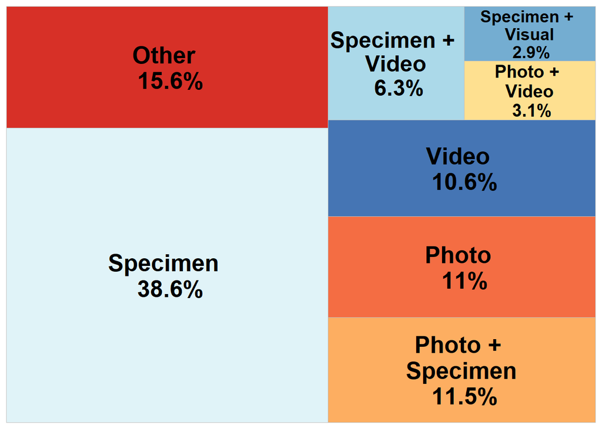

```r
library(treemapify)
library(RColorBrewer)

data_type_treemap <-
ggplot(data_type_simplified,
       aes(area=Count,
           fill=`Data type`,
           line = "black",
           label=paste0(`Data type`, " \n ",Percentage,"%"))
       )+
  treemapify::geom_treemap(layout = "squarified")+
  geom_treemap_text(place = "centre", fontface = "bold",
                    size = 20)+
    theme(plot.title = element_text(hjust = 0.5, size= 20),
          legend.position = "none")+
    scale_fill_brewer(palette = "RdYlBu")

data_type_treemap
```

```r
ggsave("data_type_treemap.png",
       plot = data_type_treemap,
       units = "in", width = 7, height = 6,
       path = here ("Extracted_data_analysis",                        "tropical",                        "Output-Visualization"))
```

# 13 HABIT

```r
habit <- as.data.frame(count_results["habit"])

# Rename columns
habit %<>%
  rename(Habit = habit.habit,
         Count = habit.Count,
         Percentage = habit.Percentage)
```

Make the habit donut plot

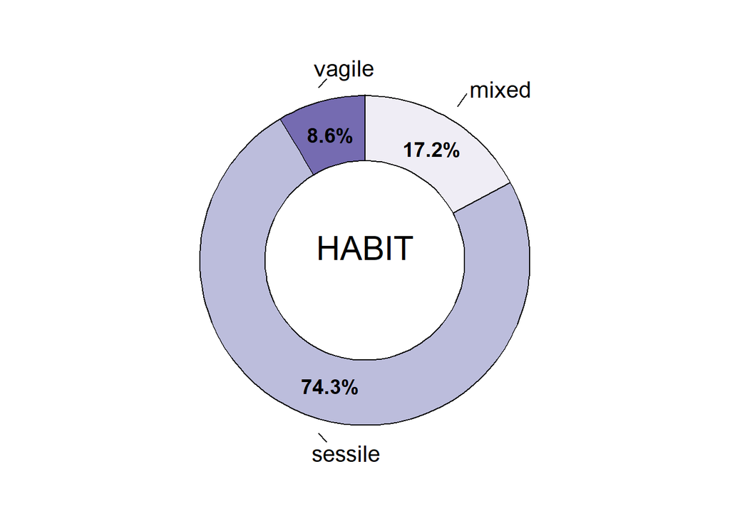

```r
habit %<>%
  mutate(ymax = cumsum(Count),
    ymin = c(0, head(ymax, n = -1)),
    mid = (ymin + ymax) / 2,
    angle = 90 - (mid / sum(Count)) * 360
  )

# Split and assign labels
habit_inside <- habit %>%
  mutate(label = paste0(round(Percentage,1), "%"))

habit_outside <- habit %>%
  mutate(label = Habit)

# Plot
habit_donut <- ggplot() +
  # Donut segments
  geom_rect(data = habit,
            aes(ymin = ymin, ymax = ymax, xmin = 2.5, xmax = 4, fill = Habit),
            color = "black") +

  # Inside labels
  geom_text(data = habit_inside,
            aes(x = 3.2, y = mid, label = label),
            size = 5, color = "black",
            fontface = "bold") +

  # Outside labels with Habit name
  ggrepel::geom_text_repel(data = habit_outside,
                  aes(x = 4.3, y = mid, label = label),
                  size = 5.5,
                  nudge_x = 0.5,
                  direction = "y",
                  segment.color = "black",
                  hjust = 0,
                  box.padding = 0.3,
                  max.overlaps = Inf) +
  coord_polar(theta = "y") +
  xlim(0.2, 5) +
  scale_fill_brewer(palette = "Purples") +
  theme_void() +
  theme(legend.position = "none")+
  annotate(geom = 'text', x = 0.5, y = 0,
           label = c("HABIT"), size = 8)

habit_donut
```

Export habit_donut

```r
ggsave("habit_donut.png",
       plot = habit_donut,
       units = "in", width = 7, height = 6,
       path = here ("Extracted_data_analysis",                        "tropical",                        "Output-Visualization"))
```

# 14 SUBSTRATE

```r
substrate <- as.data.frame(count_results["meso_substrate"])

# Rename columns
substrate %<>%
  rename(Substrate = meso_substrate.meso_substrate,
         Count = meso_substrate.Count,
         Percentage = meso_substrate.Percentage)

# Remove rows with nd
substrate <- substrate[!substrate$Substrate %in% "nd",]

# Merge substrate combination with less than 3% and recalculate Count and Percentages
substrate <- substrate %>%
  mutate(Substrate = if_else(Percentage < 3, "Other combinations", Substrate)) %>%
  group_by(Substrate) %>%
  select(-Percentage) %>%
  summarise(
    Count = sum(Count)) %>%
  mutate(Percentage = round(Count / sum(Count) * 100,1)
  )

substrate %<>%
  mutate(
    Substrate = case_when(Substrate == "hard" ~ "Hard",
                          Substrate == "soft"~ "Soft",
                          Substrate == "mixed" ~ paste0("Hard+","\n","Soft"),
                          Substrate == "artificial" ~ "Artificial",
                          Substrate == "Other combinations" ~ "Other combinations"))
```

Make the substrate donut plot

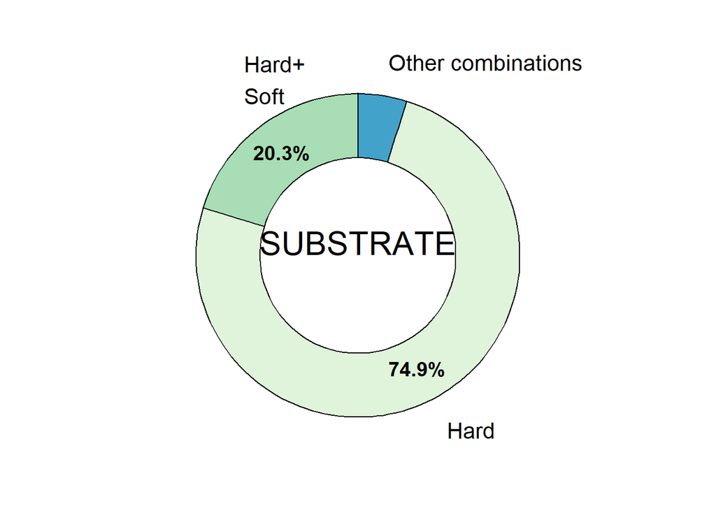

```r
substrate %<>%
  mutate(
    ymax = cumsum(Count),
    ymin = c(0, head(ymax, n = -1)),
    mid = (ymin + ymax) / 2,
    angle = 90 - (mid / sum(Count)) * 360
  )


# Split and assign labels
substrate_inside <- substrate %>%
    filter(Percentage >= 5) %>%
  mutate(label = paste0(Percentage, "%"))

substrate_outside <- substrate %>%
  mutate(label = Substrate)

# Plot
substrate_donut <- ggplot() +
  # Donut segments
  geom_rect(data = substrate,
            aes(ymin = ymin, ymax = ymax, xmin = 2.5, xmax = 4, fill = Substrate),
            color = "black") +

  # Inside labels
  geom_text(data = substrate_inside,
            aes(x = 3.2, y = mid, label = label),
            size = 5, color = "black",
            fontface = "bold") +

  # Outside labels with substrate name
  ggrepel::geom_text_repel(data = substrate_outside,
                  aes(x = 4.4, y = mid, label = label),
                  size = 5.5,
                  nudge_x = 0.3,
                  direction = "y",
                  segment.color = "black",
                  hjust = 0,
                  box.padding = 0.3,
                  max.overlaps = Inf) +
  coord_polar(theta = "y") +
  xlim(0.2, 5) +
  scale_fill_brewer(palette = "GnBu") +
  theme_void() +
  theme(legend.position = "none")+
  annotate(geom = 'text', x = 0.5, y = 0,
           label = c("SUBSTRATE"), size = 8)

substrate_donut
```

Export the substrate donut plot

```r
ggsave("substrate_donut.png",
       plot = substrate_donut,
       units = "in", width = 7, height = 6,
       path = here ("Extracted_data_analysis",                        "tropical",                        "Output-Visualization"))
```

# 15 BENTHIC POSITION

Create a data frame with benthic position

```r
position <- as.data.frame(count_results["environmentalPosition"])

# Rename columns
position %<>%
  rename(Position = environmentalPosition.environmentalPosition,
         Count = environmentalPosition.Count,
         Percentage = environmentalPosition.Percentage)

# Merge position combination with less than 3% and recalculate Count and Percentages
position <- position %>%
  mutate(Position = if_else(Percentage < 1, "Other combinations", Position)) %>%
  group_by(Position) %>%
  select(-Percentage) %>%
  summarise(
    Count = sum(Count)) %>%
  mutate(Percentage = round(Count / sum(Count) * 100,1)
  )
```

Make the benthic position donut plot

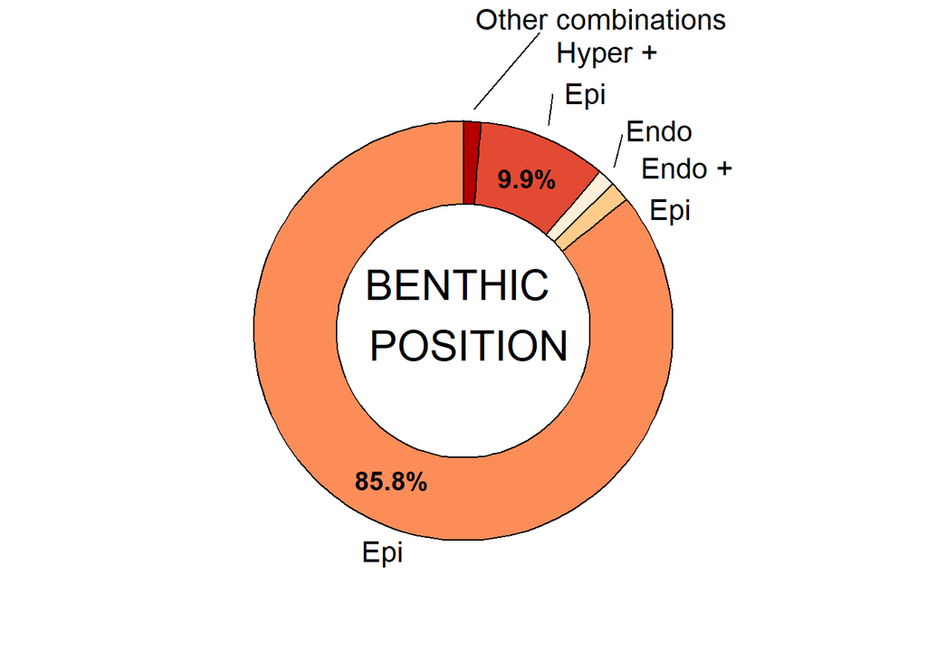

```r
position %<>%
  mutate(
    Position = case_when(Position == "epi" ~ "Epi",
                          Position == "endo"~ "Endo",
                          Position == "dem+epi" ~ "Hyper + \n Epi",
                          Position == "endo+epi" ~ "Endo + \n Epi",
                          Position == "Other combinations" ~ "Other combinations"),
    ymax = cumsum(Count),
    ymin = c(0, head(ymax, n = -1)),
    mid = (ymin + ymax) / 2,
    angle = 90 - (mid / sum(Count)) * 360
  )


# Split and assign labels
position_inside <- position %>%
  filter(Percentage > 3) %>%
  mutate(label = paste0(Percentage, "%"))

position_outside <- position %>%
  mutate(label = Position)

# Plot
benthic_position_donut <- ggplot() +
  # Donut segments
  geom_rect(data = position,
            aes(ymin = ymin, ymax = ymax, xmin = 2.5, xmax = 4, fill = Position),
            color = "black") +

  # Inside labels
  geom_text(data = position_inside,
            aes(x = 3.2, y = mid, label = label),
            size = 5, color = "black",
            fontface = "bold") +

  # Outside labels with Position name
  ggrepel::geom_text_repel(data = position_outside,
                  aes(x = 4.2, y = mid, label = label),
                  size = 5.5,
                  nudge_x = 0.3,
                  direction = "y",
                  segment.color = "black",
                  hjust = 0,
                  box.padding = 0.3,
                  max.overlaps = Inf) +
  coord_polar(theta = "y") +
  xlim(0.2, 5) +
  scale_fill_brewer(palette = "OrRd") +
  theme_void() +
  theme(legend.position = "none")+
  annotate(geom = 'text', x = 0.5, y = 0,
           label = c("BENTHIC \n POSITION"), size = 8)

benthic_position_donut
```

Export the benthic_position donut plot

```r
ggsave("benthic_position_donut.png",
       plot = benthic_position_donut,
       units = "in", width = 7, height = 6,
       path = here ("Extracted_data_analysis",                        "tropical",                        "Output-Visualization"))
```

# 16 TARGET

## 16.1 Target level

```r
target_level <- as.data.frame(count_results["taxonomicTargetLevel"])

# Rename columns
target_level %<>%
  rename(Level = taxonomicTargetLevel.taxonomicTargetLevel,
         Count = taxonomicTargetLevel.Count,
         Percentage = taxonomicTargetLevel.Percentage)

# Remove rows with nd
target_level <- target_level[!target_level$Level %in% "species,species",]
target_level <- target_level[!target_level$Level %in% ",species",]

# Merge habit combination with less than 3% and recalculate Count and Percentages
target_level <- target_level %>%
  mutate(Level = if_else(Percentage < 3, "Other combinations", Level)) %>%
  group_by(Level) %>%
  select(-Percentage) %>%
  summarise(
    Count = sum(Count)) %>%
  mutate(Percentage = round(Count / sum(Count) * 100,1)
  )
```

Treemap with the taxonomic target level

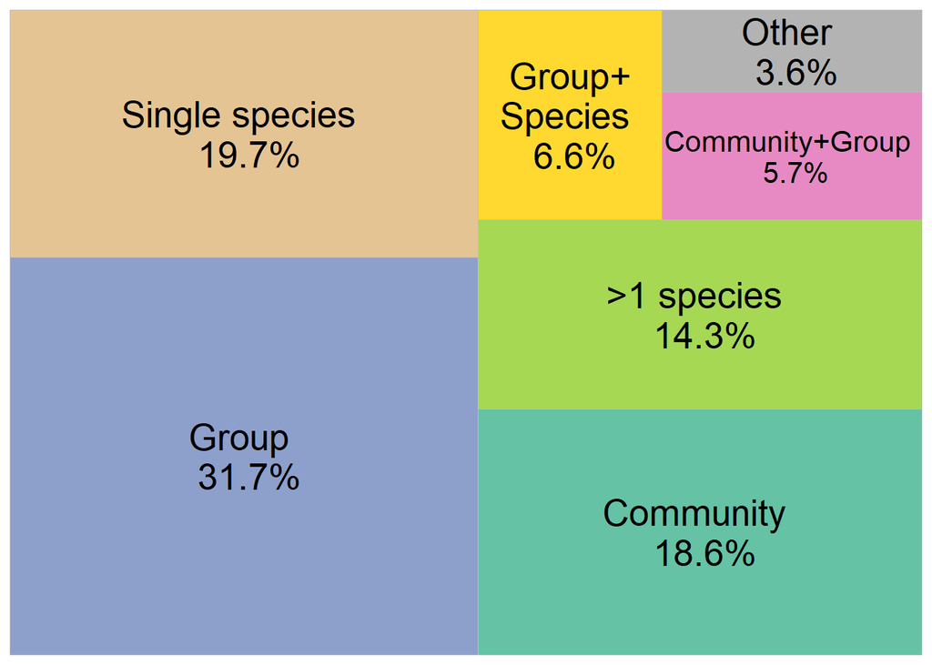

```r
target_level_labels <- target_level %<>%
  mutate(
    Level = case_when(Level == "comm" ~ "Community",
                      Level == "group"~ "Group",
                      Level == "single" ~ "Single species",
                      Level == "species" ~ ">1 species",
                      Level == "comm+group" ~ "Community+Group",
                      Level == "comm+species" ~ "Community+Species",
                      Level == "group+species" ~ "Group+\nSpecies",
                      Level == "Other combinations" ~ "Other")
    )

target_level_treemap <- ggplot(target_level_labels,
       aes(area=Count,
           fill=Level,
           line = "black",
           label=paste0(Level,
                        " \n ",Percentage,"%"))
       )+
  treemapify::geom_treemap(layout = "squarified")+
  treemapify::geom_treemap_text(place = "centre",
                    size = 20)+
    theme(plot.title = element_text(hjust = 0.5, size= 20),
          legend.position = "none")+
  scale_fill_manual(values= c("#A6D854" ,"#66C2A5","#E78AC3", "#8DA0CB","#FFD92F","#B3B3B3", "#E5C494", "#FC8D62"))

target_level_treemap
```

```r
ggsave("target_level_treemap.png",
       plot = target_level_treemap,
       units = "in", width = 9, height = 6,
       path = here ("Extracted_data_analysis",                        "tropical",                        "Output-Visualization"))
```

## 16.2 Detected phyla in community studies

```r
detected <- tropical %>%
    filter(str_detect(taxonomicTargetLevel,"comm")) %>%
  select(File,
         detected_meso_cnidaria,
         detected_meso_sponges,
         detected_meso_seagrass,
         detected_meso_algae,
         detected_meso_mollusca,
         detected_meso_chondrichthyes,
         detected_meso_fish,
         detected_meso_crustacea,
         detected_meso_echino,
         detected_meso_other_taxa)
```

```r
detected_lvls <-
  unique(
    unlist(
      str_split(detected$detected_meso_other_taxa, "\\+")
                               )
                        )
detected_lvls<- detected_lvls[! detected_lvls %in% c("",NA,"notapp",",","nd")]
detected[,detected_lvls] <- sapply(detected_lvls,
                                      function(y){
                                        str_count(detected$detected_meso_other_taxa, y)
                                        }
                                      )

rm(detected_lvls)

detected %<>%
  mutate(across(everything(), as.character)) %>%
  replace(is.na(.), "0") %>%
  select(-detected_meso_other_taxa) %>%
  filter(if_all(everything(), ~ !grepl("notapp", .x)))

detected <- detected %>%
  mutate(across(-File, ~ case_when(
    .x %in% c("x", "x,", "xx") ~ "1",
    .x == "," ~ "0",
    TRUE ~ .x
  ))) %>%
  mutate(across(-File, as.numeric))
```

Calculate number of publications per taxonomic group

```r
detected_tot <-
  detected %>%
  summarise(across(where(is.numeric),
                   list(sum)
                   )
            )

detected_tot  <- reshape2::melt(detected_tot, id.vars = NULL)

colnames(detected_tot) <- c("Taxa", "Count")

detected_tot %<>%
        mutate_at("Taxa",
                  stringr::str_replace, "_1", "") %>%
        mutate_at("Taxa",
                  stringr::str_replace, "detected_meso_", "")


detected_tot %<>%
      mutate(Percentage= round(Count / nrow(detected) * 100,1))

rm(detected)
```

Merge poorly represented taxonomic groups into “Other”

```r
detected_tot_collapsed <- detected_tot %>%
  mutate(Taxa = if_else(Percentage < 3, "Other", Taxa)) %>%
  group_by(Taxa) %>%
  summarise(
    Count = sum(Count),
    Percentage = sum(Percentage)
  )
```

Create a bar chart with detected taxonomic groups

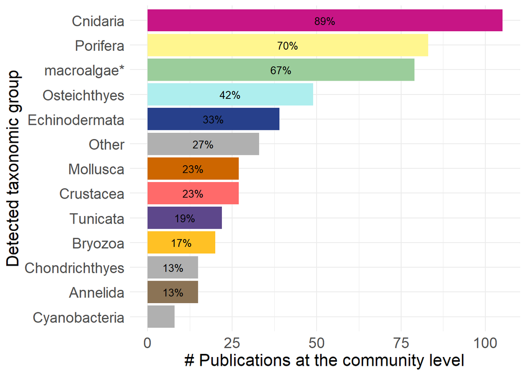

```r
detected_bar <- ggplot(detected_tot_collapsed, aes(x = reorder(Taxa, Count), y = Count, fill= Taxa)) +
  geom_bar(stat = "identity") +
  geom_text(
    data = detected_tot_collapsed %>% filter(Percentage > 11),
    aes(label = paste0(round(Percentage, 0), "%")),
    position = position_stack(vjust = 0.5),
    color = "black",
    size = 3.5
  )+
  labs(y = "# Publications at the community level", x = "Detected taxonomic group") +
  theme_minimal() +
  coord_flip()+  # optional: flips for horizontal bars
  theme(legend.position ="none")+
  scale_x_discrete(labels = rev(c("Cnidaria",
                                "Porifera",
                                "macroalgae*",
                                "Osteichthyes",
                                "Echinodermata",
                                "Other",
                                "Mollusca",
                                "Crustacea",
                                "Tunicata",
                                "Bryozoa",
                            "Chondrichthyes",
                                "Annelida",
                            "Cyanobacteria")))

detected_palette <- c("algae" ="darkseagreen3",
                      "cnidaria" = "mediumvioletred",
                      "crustacea" = "indianred1",
                      "sponges" = "khaki1",
                      "mollusca" = "darkorange3",
                      "fish" = "paleturquoise2",
                      "echino" = "royalblue4",
                      "Tunicata" = "mediumpurple4",
                      "chondrichthyes" = "gray69",
                      "Brachiopoda" = "gray69",
                      "Other" = "gray69",
                      "Cyanobacteria" = "gray69",
                      "Bryozoa" = "goldenrod1",
                      "Annelida" = "burlywood4")


detected_bar +
  scale_fill_manual(values = detected_palette,
    limits = names(detected_palette))+
  theme(axis.text = element_text(size = 14),
        axis.title = element_text(size = 16)
        )
```

```r
ggsave("detected_bar.png",
       units = "in", width = 7, height = 6,
       path = here ("Extracted_data_analysis",                        "tropical",                        "Output-Visualization"))
```

## 16.3 Target taxonomic groups not at the community level

```r
group <- tropical %>%
    filter(taxonomicTargetLevel != "comm") %>%
  select(File,
         detected_meso_cnidaria,
         detected_meso_sponges,
         detected_meso_seagrass,
         detected_meso_algae,
         detected_meso_mollusca,
         detected_meso_chondrichthyes,
         detected_meso_fish,
         detected_meso_crustacea,
         detected_meso_echino,
         detected_meso_other_taxa,
         targetTaxa)
```

```r
group_lvls <-
  unique(
    unlist(
      str_split(group$detected_meso_other_taxa, "\\+")
                               )
                        )
group_lvls<- group_lvls[! group_lvls %in% c("",NA,"notapp",",","nd")]
group[,group_lvls] <- sapply(group_lvls,
                                      function(y){
                                        str_count(group$detected_meso_other_taxa, y)
                                        }
                                      )

rm(group_lvls)
```

```r
group <- group %>%
  mutate(across(everything(), as.character)) %>%
  replace(is.na(.), "0") %>%
  select(-detected_meso_other_taxa,-targetTaxa) %>%
  filter(if_all(everything(), ~ !grepl("notapp", .x))) %>%
  mutate(across(-File, ~ case_when(
    .x %in% c("x", "x,", "xx") ~ "1",
    .x == "," ~ "0",
    TRUE ~ .x
  ))) %>%
  mutate(across(-File, as.numeric))
```

```r
group_tot <-
  group %>%
  summarise(across(where(is.numeric),
                   list(sum)
                   )
            )

group_tot  <- reshape2::melt(group_tot, id.vars = NULL)

colnames(group_tot) <- c("Taxa", "Count")

group_tot %<>%
        mutate_at("Taxa",
                  stringr::str_replace, "_1", "") %>%
        mutate_at("Taxa",
                  stringr::str_replace, "detected_meso_", "")


group_tot %<>%
      mutate(Percentage= round(Count / nrow(group) * 100,1))
```

```r
group_tot_collapsed <- group_tot %>%
  mutate(Taxa = if_else(Percentage < 3, "Other", Taxa)) %>%
  group_by(Taxa) %>%
  summarise(
    Count = sum(Count),
    Percentage = sum(Percentage),
    .groups = "drop"
  )
```

```r
group_tot_collapsed %<>%
  mutate(Taxa = case_when(Taxa == 'echino' ~ "Echinodermata",
                          Taxa == 'fish' ~ "Osteichthyes",
                          Taxa == "Symbiodiniaceae" ~ "Symbiodiniaceae",
                          Taxa == "sponges" ~ "Porifera",
                          Taxa == "crustacea" ~ "Crustacea",
                          Taxa == "cnidaria" ~ "Cnidaria",
                          Taxa == "algae" ~ "macroalgae*",
         .default = Taxa))
```

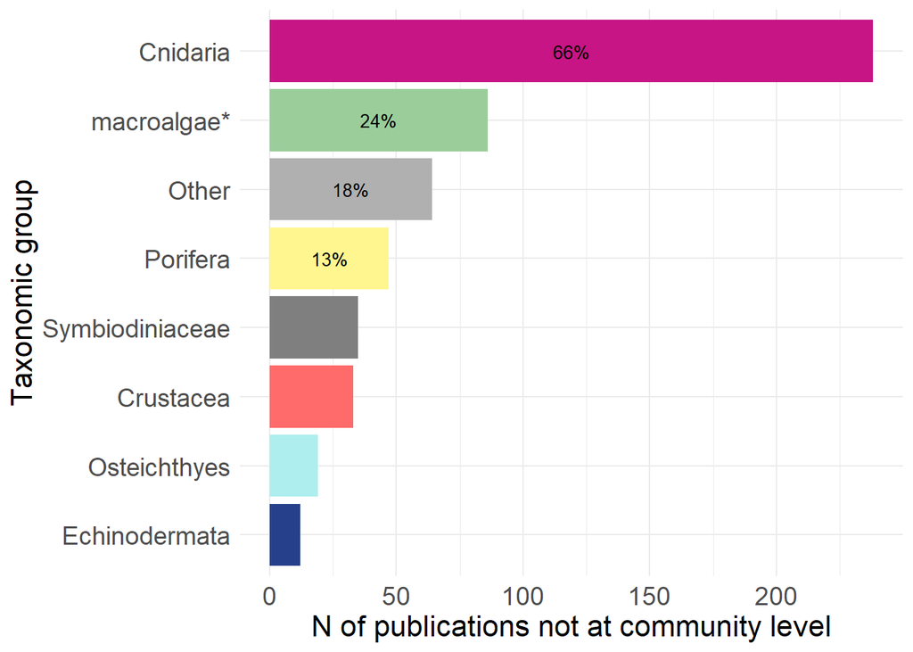

```r
group_bar <- ggplot(group_tot_collapsed, aes(x = reorder(Taxa, Count), y = Count, fill= Taxa)) +
  geom_bar(stat = "identity") +
  geom_text(
    data = group_tot_collapsed %>% filter(Percentage > 10),
    aes(label = paste0(round(Percentage, 0), "%")),
    position = position_stack(vjust = 0.5),
    color = "black",
    size = 3.5
  )+
  labs(y = "N of publications not at community level", x = "Taxonomic group") +
  theme_minimal() +
  coord_flip()+  # optional: flips for horizontal bars
  theme(legend.position ="none")

group_palette <- c("macroalgae*" ="darkseagreen3",
                      "Cnidaria" = "mediumvioletred",
                      "Crustacea" = "indianred1",
                      "Porifera" = "khaki1",
                      "Mollusca" = "darkorange3",
                      "Osteichthyes" = "paleturquoise2",
                      "Echinodermata" = "royalblue4",
                      "Tunicata" = "mediumpurple4",
                      "Chondrichthyes" = "gray69",
                      "Other" = "gray69",
                      "Alismatales (seagrasses)" =  "gray69",
                      "Bryozoa" = "goldenrod1",
                      "Annelida" = "burlywood4")

group_bar <- group_bar +
  scale_fill_manual(values = group_palette,
    limits = names(group_palette))+
    theme(axis.text = element_text(size = 14),
        axis.title = element_text(size = 16)
        )

group_bar
```

Export bar plot

```r
ggsave("group_bar.png",
       plot = group_bar,
       units = "in", width = 7, height = 6,
       path = here ("Extracted_data_analysis",                        "tropical",                        "Output-Visualization"))
```

## 16.4 New species described per phyla

```r
new_spec <- tropical %>%
  filter(str_detect(taxonomic_publication, "taxa"))

new_spec %<>%
  select(File,
         detected_meso_cnidaria,
         detected_meso_sponges,
         detected_meso_seagrass,
         detected_meso_algae,
         detected_meso_mollusca,
         detected_meso_chondrichthyes,
         detected_meso_fish,
         detected_meso_crustacea,
         detected_meso_echino,
         detected_meso_other_taxa)
```

```r
new_spec_lvls <-
  unique(
    unlist(
      str_split(new_spec$detected_meso_other_taxa, "\\+")
                               )
                        )
new_spec_lvls<- new_spec_lvls[! new_spec_lvls %in% c("",NA,"notapp")]
new_spec[,new_spec_lvls] <- sapply(new_spec_lvls,
                                      function(y){
                                        str_count(new_spec$detected_meso_other_taxa, y)
                                        }
                                      )

rm(new_spec_lvls)
```

```r
new_spec  %<>%
  mutate(across(everything(), as.character)) %>%
  replace(is.na(.), "0") %>%
  select(-detected_meso_other_taxa) %>%
  filter(if_all(everything(), ~ !grepl("notapp", .x))) %>%
  mutate(across(-File, ~ case_when(
    .x %in% c("x") ~ "1",
    TRUE ~ .x
  ))) %>%
  mutate(across(-File, as.numeric))
```

```r
new_spec_tot <-
  new_spec %>%
  summarise(across(where(is.numeric),
                   list(sum)
                   )
            )

rm(new_spec)
new_spec_tot  <- reshape2::melt(new_spec_tot, id.vars = NULL)

colnames(new_spec_tot) <- c("Taxa", "Count")

new_spec_tot %<>%
        mutate_at("Taxa",
                  stringr::str_replace, "_1", "") %>%
          mutate_at("Taxa",
                  stringr::str_replace, "detected_meso_", "")


new_spec_tot %<>%
  filter(Count>0) %>%
      mutate(Percentage= round(Count / sum(Count) * 100,1))
```

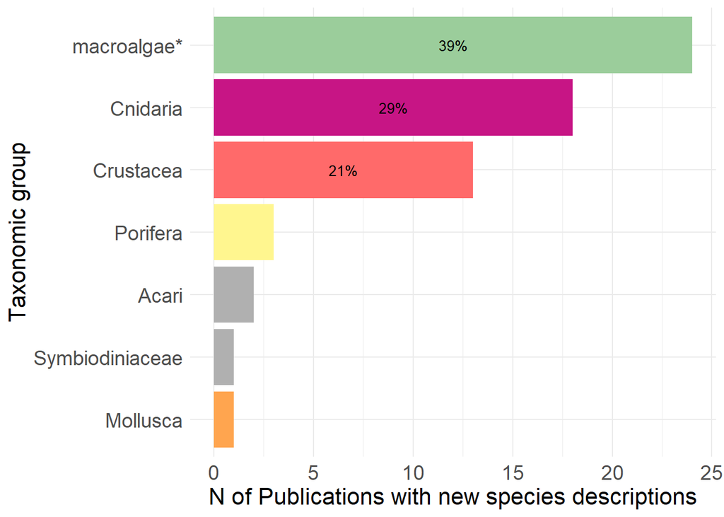

```r
new_spec_plot <-   ggplot(new_spec_tot,
                          aes(x = reorder(Taxa, Count), y = Count,
                              fill= Taxa)) +
  geom_bar(stat = "identity") +
  geom_text(

    data = new_spec_tot %>% filter(Percentage > 8),
    aes(label = paste0(round(Percentage, 0), "%")),
    position = position_stack(vjust = 0.5),
    color = "black",
    size = 3.5
  )+
  labs(y = "N of Publications with new species descriptions", x = "Taxonomic group") +
  theme_minimal() +
  coord_flip()+  # optional: flips for horizontal bars
  theme(legend.position ="none")+
  scale_x_discrete(labels = rev(c("macroalgae*",
                                "Cnidaria",
                                "Crustacea",
                                "Porifera",
                                "Acari",
                                "Symbiodiniaceae",
                                "Mollusca"))
                   )

new_spec_palette <- c("algae" ="darkseagreen3",
                      "cnidaria" = "mediumvioletred",
                      "crustacea" = "indianred1",
                      "sponges" = "khaki1",
                      "mollusca" = "tan1",
                      "Acari" = "gray69",
                      "Symbiodiniaceae" = "gray69")

new_species_bar <- new_spec_plot +
  scale_fill_manual(values = new_spec_palette,
    limits = names(new_spec_palette))+
    theme(axis.text = element_text(size = 14),
        axis.title = element_text(size = 16)
        )

new_species_bar
```

Export bar plot

```r
ggsave("new_species_bar.png",
       plot = new_species_bar,
       units = "in", width = 7, height = 6,
       path = here ("Extracted_data_analysis",                        "tropical",                        "Output-Visualization"))
```

## 16.5 New species descriptions that included molecular analyses

```r
new_spec_molecular <- tropical %>%
  filter(str_detect(taxonomic_publication, "taxa") &
           molecularAnalyses != "no" &
           molecularAnalyses != "nd" &
           molecularAnalyses != "notapp")

nrow(new_spec_molecular)
```

```
## [1] 29
```

# 17 DATA CROSSING

```r
table(tropical$meso_protection)
```

```
##
## mixed    nd    no   yes
##    34   346    14    51
```

## 17.1 VISUALLY SURVEYED SURFACE

```r
tropical$visuallySurveyedSurface <- as.factor(tropical$visuallySurveyedSurface)
summary(subset(tropical, is.na(tropical$taxonomic_publication))$visuallySurveyedSurface)
```

```
##       <1       >1      >10     >100    >1000   >10000  >100000 >1000000
##        1        6       23       50       30       11        9        3
##       nd   notapp
##      171       80
```

## 17.2 Observation

```r
print(paste("Number of manipulative experimental studies:",nrow(subset(tropical, grepl("exp", tropical$observationalORexperimental)))))
```

```
## [1] "Number of manipulative experimental studies: 66"
```

```r
print(paste("Number of manipulative experimental studies in the field of restoration:", nrow(subset(tropical, grepl("exp", tropical$observationalORexperimental) & tropical$field_rest != 0)
                                                                                            )
            )
      )
```

```
## [1] "Number of manipulative experimental studies in the field of restoration: 0"
```

## 17.3 Temp replicates & exp

```r
print(paste("# Publications that included temporal replicates:", nrow(subset(tropical, grepl("yes", temporalReplicates)))))
```

```
## [1] "# Publications that included temporal replicates: 106"
```

```r
print(paste("# Publications that included temporal replicates:", nrow(subset(tropical, (grepl("exp", tropical$observationalORexperimental) & grepl("yes", temporalReplicates))))))
```

```
## [1] "# Publications that included temporal replicates: 43"
```

## 17.4 Health

```r
health <- subset(tropical, grepl("Health", indicators) | grepl("Disease", indicators))

unique(health$targetTaxa)
```

```
##  [1] "Agaricia_grahamae+Agaricia_undata+Madracis_pharensis"
##  [2] "Scleractinia"
##  [3] "Alveopora_allingi+Alveopora_ocellata"
##  [4] "Xestospongia_muta"
##  [5] "Amphiprion_chrysopterus"
##  [6] "notapp"
##  [7] "Scleractinia+Sarcophyton_spp"
##  [8] "Antipathes_dichotoma+Antipathes_grandis+Carijoa_riisei"
##  [9] "Leptoseris_fragilis+Symbiodiniaceae"
## [10] "Agaricia_lamarcki"
## [11] "Montastraea_cavernosa+Siderastrea_stellata"
## [12] "Stylophora_pistillata+Symbiodiniaceae"
## [13] "Seriatopora_hystrix"
## [14] "Ectocarpus_sp+Clodophora_sp+Lyngbya_sp+Pseudoanabaena_sp"
## [15] "Plakortis_angulospiculatus"
## [16] "Antillogorgia_bipinnata+Ellisella_elongata+Octocorallia+Porifera"
## [17] "Anthozoa"
## [18] "Orbicella_spp"
## [19] "Montastraea_cavernosa+Symbiodiniaceae"
## [20] "Agaricia_lamarcki+Orbicella_franksi"
```

## 17.5 ROV & sample

```r
rov <- subset(tropical, grepl("rov", meso_samplingPlatform) )

rov_specimen <- subset(rov,  grepl("specimen", collectedDataType) )

print(paste("Percentage of publications relying solely on ROV where specimens were collected:", round(nrow(rov_specimen)/nrow(rov)*100,1),"%"))
```

```
## [1] "Percentage of publications relying solely on ROV where specimens were collected: 60.4 %"
```

```r
rm(rov, rov_specimen)
```

## 17.6 Molecular techniques in taxonomic and non-taxonomic studies

```r
tropical$taxonomic_publication <- as.factor(tropical$taxonomic_publication )

molecular <- tropical %>%
  filter(molecularAnalyses != "no" &
           molecularAnalyses != "notapp" &
           molecularAnalyses != "nd")

print(paste("# Publications that adopted molecular techniques: ",nrow(molecular)))
```

```
## [1] "# Publications that adopted molecular techniques:  119"
```

```r
molecular_notaxa <- molecular %>%
  filter(is.na(taxonomic_publication))

print(paste("# Publications that adopted molecular techniques not for taxonomy: ",nrow(molecular_notaxa)))
```

```
## [1] "# Publications that adopted molecular techniques not for taxonomy:  90"
```

```r
rm(molecular, molecular_notaxa)
```

```r
library(report)
report::report(sessionInfo())
```

```
## Analyses were conducted using the R Statistical language (version 4.5.2; R Core
## Team, 2025) on Windows 11 x64 (build 26200), using the packages magrittr
## (version 2.0.4; Bache S, Wickham H, 2025), report (version 0.6.3; Makowski D et
## al., 2023), here (version 1.0.2; Müller K, 2025), tibble (version 3.3.1; Müller
## K, Wickham H, 2026), RColorBrewer (version 1.1.3; Neuwirth E, 2022), openxlsx
## (version 4.2.8.1; Schauberger P, Walker A, 2025), ggplot2 (version 4.0.2;
## Wickham H, 2016), stringr (version 1.6.0; Wickham H, 2025), readxl (version
## 1.4.5; Wickham H, Bryan J, 2025), dplyr (version 1.2.0; Wickham H et al.,
## 2026), purrr (version 1.2.1; Wickham H, Henry L, 2026) and treemapify (version
## 2.6.0; Wilkins D, 2025).
##
## References
## ----------
##   - Bache S, Wickham H (2025). _magrittr: A Forward-Pipe Operator for R_.
## doi:10.32614/CRAN.package.magrittr
## <https://doi.org/10.32614/CRAN.package.magrittr>, R package version 2.0.4,
## <https://CRAN.R-project.org/package=magrittr>.
##   - Makowski D, Lüdecke D, Patil I, Thériault R, Ben-Shachar M, Wiernik B (2023).
## "Automated Results Reporting as a Practical Tool to Improve Reproducibility and
## Methodological Best Practices Adoption." _CRAN_.
## doi:10.32614/CRAN.package.report
## <https://doi.org/10.32614/CRAN.package.report>,
## <https://easystats.github.io/report/>.
##   - Müller K (2025). _here: A Simpler Way to Find Your Files_.
## doi:10.32614/CRAN.package.here <https://doi.org/10.32614/CRAN.package.here>, R
## package version 1.0.2, <https://CRAN.R-project.org/package=here>.
##   - Müller K, Wickham H (2026). _tibble: Simple Data Frames_.
## doi:10.32614/CRAN.package.tibble
## <https://doi.org/10.32614/CRAN.package.tibble>, R package version 3.3.1,
## <https://CRAN.R-project.org/package=tibble>.
##   - Neuwirth E (2022). _RColorBrewer: ColorBrewer Palettes_.
## doi:10.32614/CRAN.package.RColorBrewer
## <https://doi.org/10.32614/CRAN.package.RColorBrewer>, R package version 1.1-3,
## <https://CRAN.R-project.org/package=RColorBrewer>.
##   - R Core Team (2025). _R: A Language and Environment for Statistical
## Computing_. R Foundation for Statistical Computing, Vienna, Austria.
## <https://www.R-project.org/>.
##   - Schauberger P, Walker A (2025). _openxlsx: Read, Write and Edit xlsx Files_.
## doi:10.32614/CRAN.package.openxlsx
## <https://doi.org/10.32614/CRAN.package.openxlsx>, R package version 4.2.8.1,
```

[output cut: 8 more lines]

```
##   - Wickham H, Bryan J (2025). _readxl: Read Excel Files_.
## doi:10.32614/CRAN.package.readxl
## <https://doi.org/10.32614/CRAN.package.readxl>, R package version 1.4.5,
## <https://CRAN.R-project.org/package=readxl>.
##   - Wickham H, François R, Henry L, Müller K, Vaughan D (2026). _dplyr: A Grammar
## of Data Manipulation_. doi:10.32614/CRAN.package.dplyr
## <https://doi.org/10.32614/CRAN.package.dplyr>, R package version 1.2.0,
## <https://CRAN.R-project.org/package=dplyr>.
##   - Wickham H, Henry L (2026). _purrr: Functional Programming Tools_.
## doi:10.32614/CRAN.package.purrr <https://doi.org/10.32614/CRAN.package.purrr>,
## R package version 1.2.1, <https://CRAN.R-project.org/package=purrr>.
##   - Wilkins D (2025). _treemapify: Draw Treemaps in 'ggplot2'_.
## doi:10.32614/CRAN.package.treemapify
## <https://doi.org/10.32614/CRAN.package.treemapify>, R package version 2.6.0,
## <https://CRAN.R-project.org/package=treemapify>.
```